Journal of the American Heart Association

*J Am Heart Assoc.* 2021;10:e021580. DOI: 10.1161/JAHA.121.021580

1

**SYSTEMATIC REVIEW AND META-ANALYSIS**

Efficacy of Physical Exercise to Offset

Anthracycline- Induced Cardiotoxicity: A

Systematic Review and Meta- Analysis of

Clinical and Preclinical Studies

Willeke R. Naaktgeboren

, MD*; David Binyam, BSc*; Martijn M. Stuiver

, PhD; Neil K. Aaronson

, PhD;

Arco J. Teske, MD, PhD; Wim H. van Harten

, MD, PhD; Wim G. Groen, PhD†; Anne M. May

, PhD†

BACKGROUND: Physical exercise is an intervention that might protect against doxorubicin- induced cardiotoxicity. In this meta-

analysis and systematic review, we aimed to estimate the effect of exercise on doxorubicin- induced cardiotoxicity and to

evaluate mechanisms underlying exercise- mediated cardioprotection using (pre)clinical evidence.

METHODS AND RESULTS: We conducted a systematic search in PubMed, Embase, and Cochrane Central Register of Controlled

Trials (CENTRAL) databases. Cochrane’s and Systematic Review Centre for Laboratory Animal Experimentation (SYRCLE)

risk- of- bias tools were used to assess the validity of human and animal studies, respectively. Cardiotoxicity outcomes reported

cardioprotection, yet they were not sufficient to establish whether physical exercise protects against doxorubicin- induced car-

diotoxicity. In animal studies (n=37), a pooled analysis demonstrated that forced exercise interventions significantly mitigated

in vivo and ex vivo doxorubicin- induced cardiotoxicity compared with nonexercised controls. Similar yet slightly smaller effects

were found for voluntary exercise interventions. We identified oxidative stress and related pathways, and less doxorubicin

accumulation as mechanisms underlying exercise- induced cardioprotection, of which the latter could act as an overarching

mechanism.

CONCLUSIONS: Animal studies indicate that various exercise interventions can protect against doxorubicin- induced cardiotoxic-

ity in rodents. Less doxorubicin accumulation in cardiac tissue could be a key underlying mechanism. Given the preclinical

evidence and limited availability of clinical data, larger and methodologically rigorous clinical studies are needed to clarify the

role of physical exercise in preventing cardiotoxicity in patients with cancer.

REGISTRATION: URL: https://www.crd.york.ac.uk/prospero; Unique identifier: CRD42019118218.

**Key Words:** anthracyclines ■ cardiotoxicity ■ exercise ■ meta- analysis

**A**

nthracyclines are a group of antineoplastic anti-

biotics that play an important role in the treat-

ment of a wide variety of cancers. However, use

of anthracyclines in clinical practice is associated with

the development of severe side effects, of which ir-

reversible, dose- dependent cardiotoxicity is among

the most important.<sup>1,2</sup> In a pooled analysis of nearly

50 000 patients with cancer treated with contemporary

Correspondence to: Willeke R. Naaktgeboren, MD, Division of Psychosocial Research and Epidemiology, The Netherlands Cancer Institute, 1066 CX

Amsterdam, The Netherlands. E- mail: w.naaktgeboren@nki.nl

*W. R. Naaktgeboren and D. Binyam are co- first authors.

†W. G. Groen and A. M. May are co- senior authors.

Supplementary Material for this article is available at https://www.ahajo urnals.org/doi/suppl/ 10.1161/JAHA.121.021580

For Sources of Funding and Disclosures, see page 12.

© 2021 The Authors. Published on behalf of the American Heart Association, Inc., by Wiley. This is an open access article under the terms of the Creat ive

Commo ns Attri bution-NonCo mmerc ial- NoDerivs License, which permits use and distribution in any medium, provided the original work is properly cited, the use

is non- commercial and no modifications or adaptations are made.

*JAHA* is available at: www.ahajournals.org/journal/jaha

*J Am Heart Assoc.* 2021;10:e021580. DOI: 10.1161/JAHA.121.021580

2

Naaktgeboren et al

Physical Exercise and Cardiotoxicity

anthracycline- based chemotherapy regimens, the

incidence of clinical and subclinical cardiotoxicity

after a median follow- up of 9 years was 6% (95% CI,

3%– 9%) and 18% (95% CI, 12%– 24%), respectively.<sup>3</sup>

Cardiotoxicity of anthracyclines has been most exten-

sively studied for doxorubicin, which is currently also

the most commonly used anthracycline.

The pathogenesis of doxorubicin- induced car-

diotoxicity (DIC), although not fully elucidated, is pre-

sumably a multifactorial complex with key roles for

topoisomerase- IIβ and generation of oxidative stress.

This eventually results in double- strand DNA breaks and

mitochondrial dysfunction, leading to cardiomyocyte

apoptosis and necrosis, with loss of functional car-

diomyocytes as a result.<sup>4- 6</sup> Since the myocardium has

no regenerative capacities, this damage is irreversible.

Compared with other cardiomyopathies, doxorubicin-

induced heart failure has a particularly poor progno-

sis, with more than half of patients dying within 2 years

after diagnosis.<sup>7</sup> As a result of the increased incidence

as well as survival of patients with cancer,<sup>8</sup> DIC still

poses a real clinical challenge.

There is growing awareness of the need to develop

effective strategies to reduce DIC, of which physical

exercise (PE) interventions could be a promising non-

pharmacological method.<sup>9</sup> The potential of PE inter-

ventions to reduce DIC has been demonstrated in

numerous preclinical studies.<sup>10</sup> Nevertheless, an es-

timate of the effect of exercise on cardiotoxicity has

never been quantified. Moreover, preclinical studies

often focus on single pathways or molecular/histologi-

cal components, thereby targeting only a small fraction

of the multifaceted pathogenesis of DIC. To fully under-

stand the relative contribution of these mechanisms,

a comprehensive overview incorporating all of the hy-

pothesized pathways is necessary.

The aim of this meta- analysis and systematic review

is 2- fold: (1) to provide a pooled estimate of the effect of

PE on preventing DIC, and (2) to provide an overview of

mechanisms underlying exercise- mediated cardiopro-

tection in patients receiving doxorubicin- based che-

motherapy in (pre)clinical studies.

METHODS

The authors declare that all supporting data are

available within the article and its online supplemen-

tary files. This review was prospectively registered

in the PROSPERO register (registration number:

CRD42019118218), and the requirements for the

Preferred Reporting Items for Systematic Reviews and

Meta- Analyses (PRISMA) Statement were followed.<sup>11</sup>

The systematic search, selection of articles, internal

validity assessment, and data extraction were per-

formed by 2 independent researchers (W. R. N. and D.

B.). In cases where no consensus was reached, a third

reviewer (A. M. M.) was consulted.

Search Strategy and Study Selection

A systematic search was conducted in PubMed,

Embase, and Cochrane Central Register of Controlled

Trials (CENTRAL) databases on August 14, 2020. The

search string was a combination of search terms for

anthracyclines, cardiotoxicity, and exercise and was

developed in collaboration with an information special-

ist from the University Medical Center Utrecht, Utrecht,

the Netherlands (Data S1). The search was limited

to the English language, without a date restriction.

CLINICAL PERSPECTIVE

What Is New?

• This systematic review and meta- analysis in-

dicates that various exercise interventions can

protect against doxorubicin- induced cardiotox-

icity in rodents, with less cardiac doxorubicin

accumulation as a key underlying mechanism.

• Evidence from clinical studies is limited, yet the

observed effects are congruent with the hy-

pothesis that physical exercise can yield cardio-

protection in patients with cancer.

What Are the Clinical Implications?

• The preclinical evidence and lack of availability

of clinical data warrants larger, methodologi-

cal rigorous clinical studies to clarify the role of

physical exercise in preventing cardiotoxicity in

patients with cancer.

Nonstandard Abbreviations and Acronyms

**DIC**

doxorubicin- induced cardiotoxicity

**FS**

fractional shortening

**FTM**

forced treadmill

**HSP**

heat shock protein

**LVP**

left ventricular pressure

**MD**

mean difference

**MHC**

myosin heavy chain

**mPTP**

mitochondrial permeability transition

pore

**PE**

physical exercise

**PGC- 1****α**

peroxisome proliferator- activated

receptor- γ coactivator 1α

**SERCA2a** sarcoendoplasmic reticulum calcium

ATPase 2a

**VWR**

voluntary wheel running

*J Am Heart Assoc.* 2021;10:e021580. DOI: 10.1161/JAHA.121.021580

3

Naaktgeboren et al

Physical Exercise and Cardiotoxicity

References of included full- text articles were checked

to identify potentially relevant articles not found through

the initial search.

Eligible studies compared any type of PE interven-

tion, both single acute bouts and chronic exercise, in

combination with anthracyclines with no intervention

(ie, anthracyclines only). Outcomes included any pa-

rameters of cardiotoxicity, such as biomarkers, imag-

ing parameters, histopathology, and clinical end points

(ie, heart failure). Studies with both humans and ani-

mal subjects (with or without cancer) were eligible for

inclusion. Studies in humans, however, had to be ei-

ther randomized controlled trials with cardiotoxicity as

one of the outcomes, or mechanistic studies focusing

on underlying pathways in order to be deemed eligi-

ble. Since the effect of PE on anthracycline- induced

cardiotoxicity has been previously<sup>12</sup> documented and

might not be the same in children as in adults, given

the relevant differences that exist between children

and adults in anthracycline- induced cardiotoxicity (eg,

different pharmacokinetics of anthracyclines)<sup>13</sup> and an

increased susceptibility for cardiotoxicity in patients at

a younger age<sup>14</sup> we excluded children from our study

population. We also excluded studies combining doxo-

rubicin with any other drug or substance, and confer-

ence abstracts.

Data Extraction and Analysis

We collected data using a pretested extraction form

including information about the study population (type

of patients, sex, age), study characteristics (number

of patients per arm, duration and timing of interven-

tion), characteristics of the anthracycline administration

(timing, dose, and number of doses). Cardiotoxicity

outcomes, along with their corresponding group aver-

ages, measures of variability or spread (SD or SE), and

group size (number), were extracted and grouped into

in vivo or ex vivo analysis and human or animal stud-

ies. In cases where the results were only reported by

means of graphs, we contacted authors for numeric

data. If no response was obtained, the study was ex-

cluded for the quantitative analysis.

doxorubicin- treated

patients.

Parameters indicative of cardiac function that were de-

scribed in ≥3 studies and were considered sufficiently

clinically and statistically homogeneous were pooled.

Random effects models were used to allow for het-

erogeneous underlying treatment effects, yet results

were reanalyzed using fixed- effect models to explore

whether this yielded differences regarding the summary

inferences. Funnel plots with Egger test were used to

detect publication for outcomes that were reported by

≥10 studies.<sup>15</sup> Statistical heterogeneity among studies

was assessed via forest plots in combination with the

*I*<sup>*2*</sup> statistics before undertaking the meta- analysis and

presenting pooled results. Outcomes were structured

around the type of intervention (forced treadmill [FTM]

versus voluntary wheel running [VWR]). If a study had

both an FTM and a VWR intervention arm, a single

pairwise comparison (ie, FTM or VWR versus control)

was entered in the appropriate analysis. Continuous

outcomes were presented as mean differences (MDs)

with corresponding 95% CIs and the variance of the

effect size (*T*<sup>2</sup>).

In a subanalysis, we tested the effect of timing of the

PE intervention with respect to doxorubicin administra-

tion (ie, before [preconditioning] or concomitant with

doxorubicin treatment). If a study had multiple interven-

tion arms, the number of patients in the control group

was divided approximately evenly among the com-

parisons (forced or voluntary versus control), which

were entered as single pairwise comparisons into the

analysis. Data were analyzed with R version 3.5.1 and

RStudio version 1.1.456 (RStudio Inc.). A narrative syn-

thesis was used to systematically describe the underly-

ing mechanism for exercise- induced cardioprotection.

Risk- of- Bias Assessment

We assessed risk of bias for animal studies using

the Systematic Review Centre for Laboratory animal

Experimentation (SYRCLE) risk- of- bias tool.<sup>16</sup> We used

the Cochrane risk- of- bias tool (version 1) for human

studies.<sup>17</sup> Per category, studies could score "high,"

"low," or "unclear" for risk of bias. Authors were con-

tacted for further details in case of an unclear score.

Further internal validity was assessed via the reporting

of quality indicators. The quality indicators were scored

as "yes" or "no," corresponding to reported or unre-

ported, respectively.

RESULTS

The search yielded 1224 original articles (Figure 1).

One additional article<sup>18</sup> was identified through other

sources. After full- text screening, 40 articles were con-

sidered eligible and included in this review. References

cluded in the analysis, 3 were human randomized con-

trolled trials<sup>19- 21</sup> and the remaining 37 were conducted

in rodents. Details of all study protocols are summa-

rized in Table 1.

Characteristics of the Clinical Studies

The 3 clinical studies were all conducted in patients

with breast cancer. Two studies by Kirkham et al<sup>19</sup> used

the same population (n=24), describing the effects of

the first exercise bout before the start of doxorubicin

and cyclophosphamide– based chemotherapy, and

*J Am Heart Assoc.* 2021;10:e021580. DOI: 10.1161/JAHA.121.021580

4

Naaktgeboren et al

Physical Exercise and Cardiotoxicity

**Figure 1.** **Flow diagram depicting the search process.**

The format provided by Moger et al<sup>11</sup> in the Preferred Reporting Items for Systematic Reviews and

Meta- Analyses statement was used.

*Addi�onal records*

*iden�ﬁed through other*

*sources*

*(n = 1)*

*Records a�er duplicates removed*

*(n =968)*

*Records screened*

*(n = 968)*

*Records excluded*

*(n = 891)*

*Full-text ar�cles*

*assessed for*

*eligibility*

*(n = 77)*

*Full-text ar�cles excluded,*

*with reasons*

- Conference abstract (n = 23)

- Wrong population, model for

childhood (n = 3)

- DOX used in combination with

other drug (n = 3)

- Prospective human trial (n =

3)

- No appropriate intervention (n =

2)

- No appropriate outcomes (n =

1)

*Studies included in analysis*:

Preclinical studies *(n = 37)*

Clinical studies *(n = 3)*

*Records iden�ﬁed through*

*database searching*

*(n =1.224)*

Screening

Included

Eligibility

Iden�ﬁca�on

*J Am Heart Assoc.* 2021;10:e021580. DOI: 10.1161/JAHA.121.021580

5

Naaktgeboren et al

Physical Exercise and Cardiotoxicity

**Table 1.** **Characteristics of the Study Protocols**

Reference

Study population

Study characteristics

Doxorubicin characteristics

Patients/

animals*

Sex

Age

Experimental

groups (n)

Exercise specifications

Exercise timing

with respect

to doxorubicin

infusion

Control groups (n)

Timing of

cardiotoxicity

assessment

Timing of

doxorubicin

Dose,

mg/kg

No. of

doses

(time)

Clinical studies

Kirkham, 201719

Patients with

stage I– III

breast cancer,

scheduled for

doxorubicin-

containing

therapy

Female

50 y

Treadmill (13)

Acute: single bout of

30 min at 70% HRmax

Preconditioning

No vigorous exercise for 72 h

before and 48 h after treatment

(11)

Before first

treatment

(baseline) and

24– 48 h After

doxorubicin

treatment

24 h After

treadmill

60 mg/

m2

1

Kirkham, 201820

Patients with

stage I– III

breast cancer,

scheduled for

doxorubicin-

containing

therapy

Female

50 y

Treadmill (13)

Chronic: 4 bouts of

30 min across 6– 9 wk

before each doxorubicin

administration, 70%

HRmax

Concomitant

No vigorous exercise for 72 h

before and 48 h after treatment

(11)

Before first

treatment

(baseline) and

7– 14 d after

last treatment

24 h After

each treadmill

Mean

total

236 mg/

m2

4

(6– 9 wk)

Ma, 201821

Patients with

breast cancer,

after operation

Female

43.1 y

Treadmill (31)

Chronic: 3 d/wk for 16 wk,

70% HRmax

Concomitant

No guidance in sports,

performed normal daily

activities (33)

After last

exercise bout,

time NS

NS

NS

4 (16 wk)

Animal studies

Ahmadian,

201822

Wistar rats

Male

3 mo,

16 mo,

and

32 mo

Treadmill (8 per

group)

Chronic : 5 d/wk for 3 wk,

15– 17 m/min, 25– 39 min/d

Preconditioning

Sedentary+doxorubicin (8 per

group)

Treadmill+saline (8 per group)

24 h After

doxorubicin

24 h After

treadmill

20

1

Alihemmati,

201923

Wister rats

Male

NS

Treadmill (6)

Chronic: 5 d/wk for 6 wk,

intensity 40%– 90%

VO2max, 60 min/d

Preconditioning

Sedentary+saline (6)

Sedentary+doxorubicin (6)

Treadmill+saline (6)

72 h After

doxorubicin

After exercise

20

1

Ascensão,

200624

Wistar rats

Male

6– 8 wk

Treadmill (6)

Chronic: 5 d/wk for 14 wk.

Building up to 90 min/d,

30 m/min (grade 6%) by

wk 5

Preconditioning

Sedentary+saline (6)

Sedentary+doxorubicin (6)

Treadmill+saline (6)

24 h After

doxorubicin

24 h After

treadmill

20

1

Ascensão,

201125

Wistar rats

Male

6 wk

Treadmill (5)

Acute: single bout of

60 min, ≈5 min at 15 m/

min 0% gradient, ≈10 min

23 m/min 0% gradient,

≈45 min 25 m/min 5%

gradient

Preconditioning

Sedentary+saline (5)

Sedentary+doxorubicin (5)

Treadmill+saline (5)

5 d After

doxorubicin

24 h After

treadmill

20

1

Ascensão,

200526

Wistar rats

Male

6– 8 wk

Treadmill (10)

Chronic: 5 d/wk for 14 wk.

Building up to 30 m/min

(6% grade), 90 min/d

Preconditioning

Sedentary+saline (10)

Sedentary+doxorubicin (10)

Treadmill+saline (10)

24 h After

doxorubicin

24 h After

treadmill

20

1

(*Continued*)

*J Am Heart Assoc.* 2021;10:e021580. DOI: 10.1161/JAHA.121.021580

6

Naaktgeboren et al

Physical Exercise and Cardiotoxicity

Reference

Study population

Study characteristics

Doxorubicin characteristics

Patients/

animals*

Sex

Age

Experimental

groups (n)

Exercise specifications

Exercise timing

with respect

to doxorubicin

infusion

Control groups (n)

Timing of

cardiotoxicity

assessment

Timing of

doxorubicin

Dose,

mg/kg

No. of

doses

(time)

Ascensão,

200527

Charles River

CD1 mice

Male

6– 8 wk

ST (11)

Chronic 5 d/wk for 14 wk.

1 h/d

Preconditioning

Sedentary+saline (11)

Sedentary+doxorubicin (11)

ST+saline (11)

24 h After

doxorubicin

24 h After ST

20

1

Ashrafi, 201228

Wistar rats

Male

8 wk

Treadmill+doxorubicin

10 mg/kg (8)

Treadmill+doxorubicin

20 mg/kg (8)

Chronic: 5 d/wk for 3 wk.

15– 17 m/min, 25– 39 min/d

Preconditioning

Sedentary+saline (8)

Sedentary+doxorubicin 10 mg/

kg (8)

Sedentary+doxorubicin 20 mg/

kg (8)

Treadmill+saline (8)

24 h After

doxorubicin

24 h After

treadmill

1. 10

2. 20

1

Chicco, 200529

Spraque–

Dawley rats

Female

NS

WR (7)

Chronic:voluntary for 8 wk

Preconditioning

Sedentary+saline (6)

Sedentary+doxorubicin (7)

WR+saline (8)

During and

after perfusion

Directly after

WR, ex vivo

perfusion

10 µM

For 1 h

Chicco, 200630

Spraque-

Dawley rats

Male

NS

Treadmill (8)

Chronic: 5 d/wk for 2 wk.

15 m/min, 20 min/d

Concomitant

Sedentary+saline (6)

Sedentary+doxorubicin (8)

Treadmill+saline (6)

5 d After

exercise

During

treadmill

2.5

6 (2 wk)

Chicco, 200631

Spraque-

Dawley rats

Male

NS

Treadmill (15)

Chronic: 5 d/wk for 12 wk.

Building up to 15– 27 m/

min (0– 5% gradient),

20– 60 min/d

Preconditioning

Sedentary+saline (6)

Sedentary+doxorubicin (15)

Treadmill+saline (6)

5 d After

doxorubicin

24 h After

treadmill

15

1

Dolinsky, 201332

C57BL6 mice

Female

10 wk

Treadmill (9– 11)

Chronic: 5 d/wk for 8 wk,

building up to 18 m/min,

45 min/d

Concomitant

Sedentary+saline (9– 11)

Sedentary+doxorubicin (9– 11)

Sedentary+doxorubicin+resver

atrol (9– 11)

48 h After

exercise

During

treadmill

8

4 (4 wk)

Farzanegi,

201933

Wistar rats

NS

40– 50 wk ST (6)

Chronic: 3 d/wk for 8 wk.

Building up from 5 to

30 min/d

Concomitant

Sedentary+saline (6)

Sedentary+doxorubicin (6)

Sedentary+doxorubicin+saline

(6)

Sedentary+doxorubicin+GA (6)

ST+doxorubicin+GA (6)

Directly after

completion of

exercise

During ST in

week 1

8.5

1

Hall, 201934

Sprague-

Dawley rats

Female

10 wk

WR (8)

Chronic: voluntary for

17 wk

Preconditioning

Sedentary+saline (6)

Sedentary+CR (6)

Saline+WR (6)

Saline+CR+WR (8)

Doxorubicin (8)

CR+doxorubicin (8)

CR+doxorubicin+WR (8)

5 d After

doxorubicin

5 d After WR

15

1

Hydock, 200835

Spraque-

Dawley rats

Male

NS

Treadmill (24)

WR (21)

Chronic: 1. 5 d/wk for

10 wk. 20– 60 min/d, 20–

30 m/min (0– 18% grade).

2. voluntary for 10 wk

Preconditioning

Sedentary+saline (30)

Sedentary+doxorubicin (28)

Treadmill+saline (24)

WR+saline (20)

5 Or 10 d after

doxorubicin

24 h After

treadmill/WR

10

1

**Table 1.** **(Continued)**

(*Continued*)

*J Am Heart Assoc.* 2021;10:e021580. DOI: 10.1161/JAHA.121.021580

7

Naaktgeboren et al

Physical Exercise and Cardiotoxicity

Reference

Study population

Study characteristics

Doxorubicin characteristics

Patients/

animals*

Sex

Age

Experimental

groups (n)

Exercise specifications

Exercise timing

with respect

to doxorubicin

infusion

Control groups (n)

Timing of

cardiotoxicity

assessment

Timing of

doxorubicin

Dose,

mg/kg

No. of

doses

(time)

Hydock, 200936

Spraque-

Dawley rats

Female

NS

WR (9)

Chronic: voluntary for 7 wk Concomitant

Sedentary (10)

Sedentary+doxorubicin (8)

7 d After

doxorubicin

During WR,

after wk 1

2.5

6 (6 wk)

Hydock, 201137

Spraque-

Dawley rats

Male

NS

Treadmill (17)

WR (23)

Chronic: 5 d/wk for 10 wk.

30 m/min, 60 min/d.

Voluntary for 10 wk

Preconditioning

Sedentary+saline (11)

Sedentary+doxorubicin (14)

Treadmill+saline (12)

WR+saline (17)

4 wk After

doxorubicin

24 h After

treadmill/WR

1

10 (10 d)

Hydock, 201238

Spraque-

Dawley rats

Female

NS

WR+doxorubicindly (9)

WR+doxorubicinwk

(10)

Chronic: voluntary for

10 wk

Concomitant

Sedentary+salinedly (8)

Sedentary+salinewk (7)

Sedentary+doxorubicindly (15)

Sedentary+doxorubicinwk (10)

WR+salinedly (8)

WR+salinewk (8)

Directly after

completion of

exercise

During WR

1dly

2.5wk

15 (15 d)

6 (6 wk)

Jensen, 201339

Spraque-

Dawley rats

Female

10– 11 wk Treadmill (47– 58)

WR (40– 51)

Chronic: 5 d/wk for 10 wk.

13– 30 m/min (5%– 18%

grade), 60 min/d. Voluntary

for 10 wk

Preconditioning

Sedentary+saline (5– 9)

Sedentary+doxorubicin (38– 61)

1, 3, 5, 7

Or 9 d after

doxorubicin

24 h After

treadmill/WR

10

1

Ji, 199440

Spraque-

Dawley rats

Female

6 mo

Treadmill (7)

Treadmill+REC (7)

Acute: single bout

Until exhaustion

Treadmill+REC=30 min

recovery

Postconditioning

Sedentary+saline (13)

Sedentary+doxorubicin (7)

Treadmill+saline (6)

Treadmill+REC+saline (7)

Directly after

exercise

24 h And

30 min before

treadmill/

treadmill+REC

4

2

Kanter, 198541

Swiss White

mice

Male

5 wk

ST (20)

Chronic: 5 d/wk for 21 wk.

Building up to 1 h/d

Concomitant

Sedentary (20)

Sedentary+doxorubicin (22)

ST (21)

After 9 wk of

exercise and

after 21 wk.

Histology only

assessed after

21 wk

During

treadmill,

starting from

wk 9

4

10 (7 wk)

Kavazis, 201042

Spraque-

Dawley rats

Male

4– 6 mo

Treadmill (7)

Treadmillcold (6)

Chronic: 5 d/wk for 5 d.

30 m/min, 60 min/d. Both

in cold (4°C) and normal

temperature

Preconditioning

Sedentary+saline (8+7)

Sedentary+doxorubicin (6)

Treadmill+saline (7)

Treadmillcold+saline (6)

24 h After

doxorubicin

Directly after

treadmill

20

1

Kavazis, 201418

Spraque-

Dawley rats

Male

6 mo

Treadmill (6)

Chronic: 1 time per d for

5 d. 30 m/min, 60 min/d

Preconditioning

Sedentary+saline (6)

Sedentary+doxorubicin (6)

Treadmill+saline (6)

24 h After

doxorubicin

24 h After

treadmill

20

1

Lee, 202043

C57BL6 mice

Male

8 wk

Treadmill (10)

Chronic: 5 d/wk for 4 wk.

13 m/min, 60 min/d

Postconditioning

Sedentary+saline (10)

Sedentary+doxorubicin (10)

24 h After

exercise

24 Before

exerciseE

20

4 (4 wk)

**Table 1.** **(Continued)**

(*Continued*)

*J Am Heart Assoc.* 2021;10:e021580. DOI: 10.1161/JAHA.121.021580

8

Naaktgeboren et al

Physical Exercise and Cardiotoxicity

Reference

Study population

Study characteristics

Doxorubicin characteristics

Patients/

animals*

Sex

Age

Experimental

groups (n)

Exercise specifications

Exercise timing

with respect

to doxorubicin

infusion

Control groups (n)

Timing of

cardiotoxicity

assessment

Timing of

doxorubicin

Dose,

mg/kg

No. of

doses

(time)

Lien, 201544

Spraque-

Dawley rats

Male

10 wk

Treadmill+

doxorubicin 10 mg/

kg (10)

Treadmill+

doxorubicin 15 mg/

kg (13)

WR+doxorubicin

10 mg/kg (10)

WR+doxorubicin

15 mg/kg (12)

Chronic: 1 time per d for

5 d. 24 m/min, 60 min/d.

Preconditioning

Sedentary+saline (14)

Sedentary+doxorubicin 10 mg/

kg (10)

Sedentary+doxorubicin 15 mg/

kg (13)

WR+saline (13)

Treadmill+saline (13)

5 d After

doxorubicin

24 h After

treadmill/WR

10

15

1

Mackay, 201945

C57BL6 mice

Male

5 wk

Treadmill (8)

Chronic: 1 time per d

for 5 d. On 70% of max

speed, 60 min/d

Concomitant

Sedentary+saline (9)

Sedentary+doxorubicin (8)

Treadmill+saline (11)

MET+sedentary+saline (13)

MET+doxorubicin (7)

3 d After

doxorubicin

1 h After

treadmill

15

1

Marques- Aleixo,

201546

Spraque-

Dawley rats

Male

6 wk

Treadmill (6)

WR (6)

Chronic: 5 d/wk for 12 wk,

18– 27 m/min, 60 min/d.

Voluntary: 12 wk

Concomitant

Sedentary+saline (6)

Sedentary+doxorubicin (6)

Treadmill+saline (6)

WR+saline (6)

48 h After

exercise

During

treadmill/WR,

starting from

wk 5

2

7 (7 wk)

Marques- Aleixo,

201847

Spraque-

Dawley rats

Male

6 wk

Treadmill (NS)

WR (NS)

Chronic:. 5 d/wk for 14 wk,

18– 27 m/min, 60 min/d.

Voluntary: 14 wk

Concomitant

Sedentary+saline (NS)

Sedentary+doxorubicin (NS)

Treadmill+saline (NS)

WR+saline (NS)

48 h After

exercise

During

treadmill/WR,

starting from

wk 5

2

7 (7 wk)

Morton, 201948

Spraque-

Dawley rats

Female

6 mo

Treadmill (10)

Chronic: 5 d/wk for 2 wk.

30 m/min, 60 min/d

Preconditioning

Sedentary+saline (10)

Sedentary+doxorubicin (10)

Treadmill+saline (10)

48 h After

doxorubicin

24 h After

treadmill

20

1

Parry, 201549

Fischer 344

rats (inoculated

with tumor cells

after wk 11)

Female

12 wk

WR (36)

Chronic: voluntary for

12– 13 wk

Preconditioning

Sedentary+saline (30)

Sedentary+doxorubicin (36)

WR+saline (30)

1, 3, Or

5 d after

doxorubicin

24 h After

tumor

reached 1 cm

12

1

Pfannenstiel,

201850

Spraque-

Dawley rats

Male

10 wk

RT (15)

Chronic: RT for 12 wk by

encouraging rats to stand

up heightening the food/

water supply

Preconditioning

Sedentary+saline (9)

Sedentary+doxorubicin (15)

RT+saline (9)

5 d After

doxorubicin

24 h After RT

12.5

1

Phungphong,

202051

Sprague-

Dawley rats

Female

9 wk

Treadmill

Chronic: 5 d/wk for 14 d,

21 m/min, 2x 10– 30 min/d

Concomitant

Sedentary/sham operated (11)

OVX (12)

OVX+doxorubicin (11)

OVX+doxorubicin+estrogen (12)

OVX+doxorubicin+mast cell

stabilizer (13)

48 h After

exercise

During

treadmill

2.5

6 (2 d)

**Table 1.** **(Continued)**

(*Continued*)

*J Am Heart Assoc.* 2021;10:e021580. DOI: 10.1161/JAHA.121.021580

9

Naaktgeboren et al

Physical Exercise and Cardiotoxicity

Reference

Study population

Study characteristics

Doxorubicin characteristics

Patients/

animals*

Sex

Age

Experimental

groups (n)

Exercise specifications

Exercise timing

with respect

to doxorubicin

infusion

Control groups (n)

Timing of

cardiotoxicity

assessment

Timing of

doxorubicin

Dose,

mg/kg

No. of

doses

(time)

Shirinbayan,

201252

Wistar rats

Male

10 wk

Treadmill (8)

Chronic: 5 d/wk for 3 wk,

15– 17 m/min, 23– 39 min/d

Preconditioning

Sedentary+saline (8)

Sedentary+doxorubicin 10 mg/

kg (8)

Sedentary+doxorubicin 20 mg/

kg (8)

Treadmill+saline (8)

24 h After

doxorubicin

24 h After

treadmill

10

20

1

Smuder, 201353

Spraque-

Dawley rats

Male

6 mo

Treadmill (6)

Chronic: 1 time per d for

10 d, building up to 30 m/

min, 60 min/d

Preconditioning

Sedentary+saline (6)

Sedentary+doxorubicin (6)

Treadmill+saline (6)

24 h After

doxorubicin

Directly after

treadmill

20

1

Sturgeon, 201454

C57BL6 mice

(injected with

melanoma

cells)

Male

6– 8 wk

Treadmill (9)

Chronic: 5 d/w for 2 wk,

10 m/min, 45 min/d

Concomitant

Sedentary+saline (7)

Sedentary+doxorubicin (8)

Treadmill+saline (8)

48 h After

exercise

During

treadmill

2

2 (2 wk)

Werner, 200855

C57BL6 mice

eNOS−/−

micecmar

TERT−/− mice

Male

8 wk

WR (6– 12)

Chronic: voluntary for 3 wk Preconditioning

Sedentary+doxorubicin (8– 12)

Sedentary (8– 12)

WR6 mo

Sedentary6 mo

NS

After WR

(further NS)

22.5

1 (24 h)

Wonders,200856

Spraque-

Dawley rats

Male

NS

Treadmill (NS)

Acute: single bout of

60 min, ≈5 min at 15 m/

min 0% gradient, ≈10 min

23 m/min 0% gradient,

≈45 min 25 m/min 5%

gradient

Preconditioning

Sedentary+saline (NS)

Sedentary+doxorubicin (NS)

Treadmill+saline (NS)

5 d After

doxorubicin

24 h after

treadmill

15

1

Yang, 202057

Sprague-

Dawley rats

Male

NS

Treadmill (8)

Chronic: 3 d/wk for 4 wk,

12 m/min, 60 min/d

Concomitant

Sedentary+saline (8)

Sedentary+doxorubicin (8)

24 h After

exercise

24 After

doxorubicin

20

15 (3/wk,

5 wk)

Experimental groups refers to the intervention these groups underwent. All of the experimental groups also underwent doxorubicin administration. Details regarding doxorubicin are shown in the Doxorubicin

characteristics columns. Doxorubicin dosages were specified in other columns in case multiple dosage groups were used. For studies reporting different numbers regarding the study populations, the largest number

reported is shown. Doxorubicin administration during exercise was started in the first week of exercise, unless otherwise stated. For Hydock, 2012, "dly" and "wk" in subscript refers to the drug administration schemes,

which were respectively daily in 15 consecutive days and weekly in 6 weeks. CR indicates calorie restriction; GA, garlic extract; HRmax, maximum heart rate; MET, metformin; NS, not specified; OVX, ovariectomized;

REC, 30 minutes of recovering after exercise; RT, resistance training; ST, swimming training; VO2max, maxium oxygen consumption; and WR, voluntary wheel running.

*The study population in the preclinical studies are animals without cancer, unless otherwise stated.

**Table 1.** **(Continued)**

*J Am Heart Assoc.* 2021;10:e021580. DOI: 10.1161/JAHA.121.021580

10

Naaktgeboren et al

Physical Exercise and Cardiotoxicity

of a total of 4 bouts on subclinical cardiotoxicity (ie,

strain and biomarkers) in the first and second report,

respectively. The PE intervention consisted of four

30- minute vigorous- intensity treadmill exercise bouts

before each administration of doxorubicin. The study

by Ma<sup>21</sup> (n=64) evaluated the effect of a 16- week PE

program during chemotherapy. Women allocated to

the intervention grouped attended three 50- minute

**A**

**B**

**C**

*J Am Heart Assoc.* 2021;10:e021580. DOI: 10.1161/JAHA.121.021580

11

Naaktgeboren et al

Physical Exercise and Cardiotoxicity

supervised treadmill sessions per week, while control

group participants were asked to maintain their normal

activity pattern. Cardiac function was assessed with

echocardiography after 4 cycles of anthracyclines.

Characteristics of the Preclinical Studies

In the 37 animal studies, conducted in mice or rats,

the type and duration of PE interventions widely

studies included both FTM and VWR.<sup>35,37,39,44,46,47</sup>

Three studies used a swimming training proto-

col,<sup>27,33,41</sup> and 1 study used a protocol to mimic

resistance training.<sup>50</sup> The duration varied from

a single bout<sup>40,56</sup> to a PE program that lasted

21 weeks.<sup>41</sup> Doxorubicin was the only anthracy-

cline administrated with variation in cumulative

dose, number and frequency of doses, and timing

with respect to the exercise intervention (ie, pre-

conditioning, concomitant with doxorubicin treat-

ment, or postconditioning). Cumulative doxorubicin

dose varied between 4 mg/kg and 100 mg/kg, with

20 mg/kg being the most used dosage (n=14). The

majority of the studies (n=23) used a precondition-

ing protocol, where doxorubicin was administrated

up to 24 hours after completion of the intervention.

Twelve studies had protocols in which, at least to

some extent, doxorubicin treatment ran parallel to

the PE intervention, and 2 studies used a postcon-

ditioning protocol.<sup>40,43</sup>

Last, cardiotoxicity was described via various out-

comes, including left ventricular (LV) function and mor-

phology, histopathology, and biochemical analysis.

The former was assessed in vivo as well as ex vivo

using echocardiography or isolated heart perfusion,

respectively.

et al were overall scored as low risk of bias, while the

study by Ma was rated as having relatively low meth-

odological quality. The animal studies widely varied in

terms of risk of bias, with most studies scoring low on

the items of selection and attrition bias, and relatively

high on the risk of performance bias. Risk of publica-

tion bias, ie, detected by asymmetry in the funnel plots,

was not assessed since no outcomes were reported

by ≥10 studies.

Effect of Exercise on DIC

*Clinical Studies*

A total of 3 studies reported about PE on anthracycline-

induced cardiotoxicity in patients with cancer. However,

results were not pooled since 2 reports made use of

the same study population and had substantial clini-

cal differences (eg, duration of PE intervention and

timing of outcome assessment) compared with the

third study. The first study by Kirkham et al<sup>19</sup> showed

that a single treadmill session mitigated an increase

in NT- proBNP (N- terminal pro- B- type natriuretic pep-

tide) 24 to 48 hours after the first anthracycline treat-

ment. Nevertheless, echocardiographic parameters,

including strain, were comparable between the exer-

port,<sup>20</sup> the 4 exercise bouts did not prevent a rise in

cardiac biomarkers (NT- proBNP and cardiac troponin).

Longitudinal strain and LV ejection fraction remained

unchanged in both groups before and after chemother-

apy. However, the authors reported that the PE group

had fewer changes in hemodynamics than the control

group. The last study reported that, in the PE group

(n=31), LV ejection fraction significantly increased after

chemotherapy (from 55%±3.5% to 60%±2.9%), while a

decrease (51%±5.6% to 47%±2.6%, *P*<0.05) was ob-

served in the control group (n=33). However, between-

group differences were not presented and risk of bias

was high.<sup>21</sup>

*Animal Studies: Pooled Analysis on In Vivo*

*Cardiotoxicity*

All animal studies that assessed in vivo parameters of

cardiotoxicity (n=13),‡ used echocardiographic- derived

fractional shortening (FS) as a marker for systolic LV

function. All studies used a treadmill intervention as PE

program, except for 1 study that used a protocol to

mimic resistance training.<sup>50</sup> Results of this study, as

well as those from a study where no numeric data

‡References 32,34,35,37– 39,44,48,49,50,51,54,57

**studies (C).**

**A**, Results of the risk of bias assessment for human studies. The risk of bias was assessed using the Cochrane risk of bias tool. The

color of the cells depicts the estimated risk of bias for the studies shown on the y- axis in the categories shown on the x- axis. Green,

yellow, and red cells represent a low, unclear, and high risk of bias, respectively. Blinding of participants was not possible because

of the nature of the intervention. **B**, Results of the risk of bias assessment for animal studies. The risk of bias was assessed using the

Systematic Review Centre for Laboratory Animal Experimentation (SYRCLE) risk of bias tool. Shown are the percentages of studies

that were judged to have an “unclear,” “low,” or “high” risk of bias in the categories depicted on the y- axis. **C**, The reporting of quality

indicators for animal studies. Shown are the percentages of studies that did or did not report (reported or not reported, respectively)

the quality indicators depicted on the y- axis.

*J Am Heart Assoc.* 2021;10:e021580. DOI: 10.1161/JAHA.121.021580

12

Naaktgeboren et al

Physical Exercise and Cardiotoxicity

could be obtained,<sup>48</sup> were excluded from quantitative

analyses. Both of these studies found an absolute im-

provement in FS in exercised rodents as compared

with controls of 13% and ≈15%, respectively.<sup>48,50</sup>

Overall, the results of these studies demonstrated

that PE interventions are able to mitigate doxorubicin-

induced impairment in FS. For studies using FTM in-

terventions (n=8),<sup>32,35,37,39,44,51,54,57</sup> FS was significantly

higher in exercised versus nonexercised rodents

(8.4%; 95% CI, 5.4– 11.5 [*T*<sup>2</sup>=18.5]) (Figure 3A). A pooled

analysis of the 7 studies that used a VWR intervention

revealed a slightly lower MD (5.4%; 95% CI, 3.6– 7.2

[*T*<sup>2</sup>=0])<sup>34,35,37,38,39,44,49</sup> (Figure 3B).

In a subanalysis regarding the timing of the PE

intervention, ie, preconditioning (n=6)<sup>34,35,37,39,44,49</sup>

or concomitant with doxorubicin administration

(n=5),<sup>32,38,51,54,57</sup> the MD was 7.0% (95% CI, 5.2– 8.7;

*T*<sup>2</sup>=0) and 5.9% (95% CI, 1.0– 10.7; *T*<sup>2</sup>=23.8) respec-

tively. Heterogeneity was substantial in the latter su-

banalysis (*I*<sup>2</sup>=78%, chi- square test: *P*<0.01) (Data S4,

Figures S1 and S2).

*Ex Vivo Parameter: Pooled Analysis on*

*LV Pressure*

Ex vivo cardiotoxicity was assessed in 12 animal stud-

ies via retrograde isolated heart perfusion,<sup>§</sup> in which

the myocardium is perfused via the coronary system to

assess cardiac function in controlled loading condi-

tions. LV pressure (LVP), the maximum developed

pressure per time unit (dP/dt- max), and the maximum

rate decline per time unit (dP/dt- min) were measured.

LVP represents cardiac function as a whole, whereas

the latter are indicators of systolic and diastolic func-

tion, respectively.<sup>58</sup> Protocols for isolated heart perfu-

sion were mostly comparable. One exception was a

study by Chicco et al,<sup>29</sup> where doxorubicin was admin-

istrated ex vivo (ie, the hearts were transplanted before

doxorubicin administration). This study, as well as a

study that used only a single exercise bout<sup>56</sup> and a

study that used a resistance intervention,<sup>50</sup> were there-

fore excluded from the pooled analyses.

interventions (n=6),<sup>30,31,35,37,39,44</sup> our meta- analysis

yielded an MD of 19.7 mm Hg (95% CI, 14.3– 25.1;

*T*<sup>*2*</sup>=51.3) compared with the nonexercised rodents.

The MD was 16.1 mm Hg (95% CI, 11.5– 20.8; *T*<sup>*2*</sup>=50.3)

for studies with VWR interventions versus controls

(n=7).<sup>34,35,37,38,39,44,49</sup> Results of dP/dt- max and dP/

dt- min were comparable to those of LVP and are pre-

sented in Data S5 and Figures S3 through S6.

exercise- mediated cardioprotection ex vivo.<sup>26,33,41,46</sup>

§References 29– 31,34,35,37– 39,44,49,50,56

**Figure 3.** **Forest plot of forced (A) or voluntary (B) physical exercise (PE) interventions on fractional shortening on**

**echocardiography (in vivo) and of forced (C) or voluntary (D) PE interventions on isolated heart perfusion (ex vivo), compared**

**with nonexercised controls in animal studies.**

Results are presented as mean difference (MD) with 95% CI.

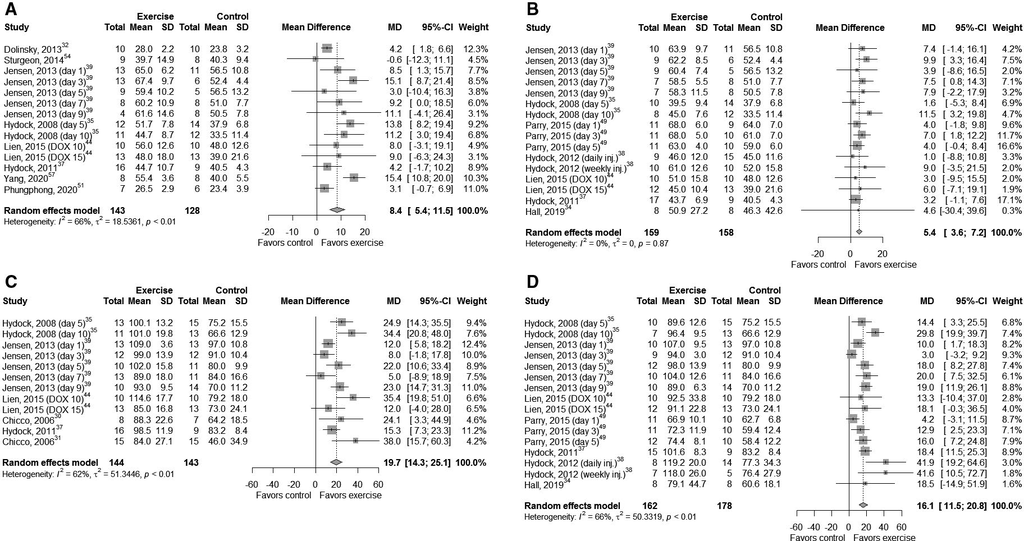

*J Am Heart Assoc.* 2021;10:e021580. DOI: 10.1161/JAHA.121.021580

13

Naaktgeboren et al

Physical Exercise and Cardiotoxicity

Although these studies were too clinically hetero-

geneous for meta- analysis, all of them showed that

microscopically established cardiac abnormalities in-

duced by doxorubicin were mitigated through exercise,

via swimming training,<sup>33,41</sup> FTM,<sup>23,26,43,46,51,57</sup> or VWR<sup>46</sup>

interventions.

The analyses of echocardiography and perfusion

parameters were repeated using fixed- effect models

and yielded no relevant differences from the results

based on the random effects models (data not shown).

Mechanisms Underlying Exercise-

Mediated Cardioprotection

Multiple pathways were addressed by the included

studies (Table 2) and were grouped into those associ-

ated with increased oxidative stress and doxorubicin

accumulation. An overview of the available studies per

pathway is presented in Table 3.

*Exercise and Oxidative Stress*

The induction of oxidative stress through inciting over-

production of reactive oxygen species is believed to

play an important role in the pathogenesis of DIC, sup-

ported by increased levels of markers of oxidative

stress, such as malondialdehyde, after doxorubicin

administration.<sup>59- 61</sup> Increased oxidative stress is related

to a variety of other pathways or proteins, including up-

regulation of antioxidants or heat- shock proteins, in-

flammation, disruption of calcium homeostasis,

autophagy, and apoptosis. Oxidative stress, or one of

the related pathways, is the most commonly reported

mechanism, with 21 studies focusing on how PE influ-

ences oxidative stress.<sup>3</sup>

Eighteen studies investigated the effects of PE on

antioxidants, which can counterbalance oxidative str

ess.<sup>22,23,24,25,26,27,28,29,30,31,32,33,40,41,42,43,46,51,52</sup> The major-

ity of these studies observed a beneficial effect of PE on

antioxidants, meaning upregulation of antioxidants in the

PE groups compared with controls. The most frequently

studied antioxidants were superoxide dismutase and

catalase. Although the effect sizes widely varied, the rel-

ative increase observed most often was in the range of

30% to 50%. In 4 of these studies, upregulation of antiox-

idants coincided with a reduction of DIC on either echo-

the role of antioxidants is ambiguous, as not all stud-

ies reported upregulation of the same antioxidants and

some studies reported conflicting results. For superox-

ide dismutase, for example, no attenuation was found

in 5 studies,<sup>25,27,29,30,31</sup> while 1 of these studies reported

upregulation of catalase<sup>27</sup> and 3 studies found a cardi-

oprotective effect of PE against DIC via isolated heart

perfusion.<sup>29- 31</sup> In contrast, in the study by Phungphong

et al using ovariectomized rats, attenuation of oxidative

stress markers by PE was observed but without preser-

vation of LV function on echocardiography.<sup>51</sup>

Heat shock proteins (HSPs) are proteins that in-

crease in various situations of cellular stress, eg,

heat shock and ischemia.<sup>62</sup> From the family of HSPs,

HSP60, HSP70, and HSP72 were investigated by 10

studies that yielded conflicting results. While the ma-

jority described significant upregulation of HSPs by

a PE intervention,<sup>22,24,26,29,31,52</sup> 1 study reported up-

regulation of some, but not all HSPs2<sup>27</sup> or even a de-

under cold conditions, which prevented upregulation

of HSP72, still yielded cardioprotection in doxorubicin-

treated rodents.

Cardiac inflammation and remodeling as a result

of oxidative stress and impaired mitochondrial func-

tion<sup>63</sup> is hypothesized to be an important pathway

in the development of DIC and may eventually lead

to increased myocardial fibrosis.<sup>57</sup> Ahmadian et al<sup>22</sup>

demonstrated that a 3- week preconditioning program

resulted in lower levels of C- reactive protein in animals

a treadmill program concomitant with doxorubicin ad-

ministration counteracted activation of an inflammatory

response (interleukin 8, tumor nectrosis factor α) and

upregulation of fibrotic markers (transforming growth

factor β1), which was supported by reduced cardiac

fibrosis and preserved systolic function on histology

and echocardiography, respectively.<sup>57</sup> Phungphong et

al,<sup>51</sup> using a 2- week treadmill program during doxoru-

bicin treatment, found no attenuation of inflammatory

markers (interleukin 6 and interleukin 10), but reported

significantly less myocardial fibrosis in the exercise

group compared with controls (7.0%±0.13% versus

8.0%±0.27% collagen deposition, respectively).

Deregulation of intracellular calcium homeosta-

sis has also been proposed as a mechanism under-

lying DIC. This is often attributed to downregulation

of sarcoendoplasmic reticulum calcium ATPase 2a

(SERCA2a).<sup>64</sup> SERCA2a is the most often expressed

isoform of sarcoendoplasmic reticulum calcium ATPase

in cardiomyocytes and is responsible for pumping cal-

cium from the cytosol into the sarcoplasmatic reticu-

lum.<sup>37</sup> Calcium is of key importance in many cardiac

functions and an interruption could result in a variety

of diseases, including systolic and diastolic dysfunc-

tion and arrhythmias.<sup>65</sup> In 2 studies, treadmill inter-

ventions of 5 days and 8 weeks, respectively, before

and during doxorubicin treatment partially prevented

downregulation of SERCA2a.<sup>32,44</sup> Lien et al,<sup>44</sup> investi-

gating doxorubicin dosages of 10 mg/kg and 15 mg/

kg in forced and voluntary exercise groups, suggested

that both exercise modalities can preserve SERCA2a,

although FTM appeared more effective with the higher

‖References 22– 24,26– 33,40,42,43,45,46,50– 52,56,57

*J Am Heart Assoc.* 2021;10:e021580. DOI: 10.1161/JAHA.121.021580

14

Naaktgeboren et al

Physical Exercise and Cardiotoxicity

**Table 2.** **Overview of Pathways Studied by the Animal Studies and Their Main Results**

Reference of

animal study

Pathway(s)

Effect of PE

intervention

Summary of main results

Ahmadian, 2018<sup>22</sup>

Marker of oxidative stress

(malondialdehyde), antioxidants (SOD),

HSP (HSP70),

inflammation markers (IL- 10, CRP)

Yes

A preconditioning exercise program had a beneficial effect on

antioxidant capacity in all 3 age groups, yet the strongest effect

was observed in the group of young rats

Alihemmati, 2019<sup>23</sup>

Apoptosis (Bax, BCL2, caspase 6, and

gene and microRNA expression)

Yes

Preconditioning high- intensity interval training attenuated

expression proapoptotic and apoptotic factors and microRNA,

counteracting myocardial apoptosis

Ascensão, 2006<sup>24</sup>

Markers of oxidative stress (gluthatione

analysis), Antioxidants (SOD), HSPs

(HSP60, HSP70), mitochondrial

respiratory functioning

Yes

Heart mitochondria of DOX- treated animals submitted to an

endurance training protocol seemed less susceptible to in vitro

anoxia- reoxygenation compared to DOX- treated sedentary

controls

Ascensão, 2011<sup>25</sup>

Antioxidants (SOD), mPTP, apoptosis

(eg, Bax, Bcl2, caspase), mitochondrial

functioning

Yes

A single exercise bout mitigated doxorubicin- induced mPTP

susceptibility and mitochondrial dysfunction and altered

apoptotic signaling compared with nonexercised controls

Ascensão, 2005<sup>26</sup>

Markers of oxidative stress

(malondialdehyde, aconitase),

antioxidants (SOD), HSPs (HSP60,

HSP70), mPTP, apoptosis (Bax, Ncl- 2),

mitochondrial functioning

Yes

An endurance treadmill exercise intervention improved

antioxidant capacity and attenuated myocardial apoptosis.

Histopathology confirmed significant attenuation of cardiotoxic

changes in the exercise vs the control group

Ascensão, 2005<sup>27</sup>

Markers of oxidative stress (gluthatione

analysis), antioxidants (SOD, catalase),

HSPs (HSP60, HSP70), cardiac troponin

I

Yes

An endurance swimming exercise program mitigated

doxorubicin- induced oxidative damage compared with controls

with positive effects on the glutathione system and HSP60

Ashrafi, 2012<sup>28</sup>

Markers of oxidative stress

(malondialdehyde, NO), antioxidants

(SOD, apelin)

Yes

A short- term PE preconditioning program counteracted

doxorubicin- induced oxidative stress and upregulated oxidative

capacity compared with nonexercised controls

Chicco, 2005<sup>29</sup>

Marker of oxidative stress

(malondialdehyde), antioxidants (SOD),

HSP (HSP72)

Yes

A voluntary wheel- running preconditioning protocol attenuated

doxorubicin- induced alterations in lipid peroxidation compared

with nonexercised controls. In addition, higher levels of HSP72

were observed in the intervention group. Cardiac function

tended to be less impaired in the trained group

Chicco, 2006<sup>30</sup>

Marker of oxidative stress

(malondialdehyde), antioxidants (SOD),

HSP (HSP72), apoptosis (caspase 3),

MHC distribution isoforms

Yes

A low- intensity treadmill exercise protocol mitigated

doxorubicin- induced cardiac dysfunction, HSP72 and

apoptotic signaling compared with nonexercised controls.

No significant effect on lipid peroxidation, SOD, or MHC

distribution was observed

Chicco, 2006<sup>31</sup>

Marker of oxidative stress

(malondialdehyde), antioxidants (SOD),

HSP (HSP72)

Yes

A preconditioning exercise program significantly mitigated

doxorubicin- induced impairments in cardiac function

compared with nonexercised controls. In addition, an increase

in lipid peroxidation and greater expression of HSP72 following

exercise was observed

Dolinsky, 2013<sup>32</sup>

Marker of oxidative stress (HNE),

antioxidants (SOD, glutathione, catalase),

SERCA2a expression

Yes

A preconditioning treadmill program counteracted doxorubicin-

induced LV dysfunction, lowered lipid peroxidation, and

increased the expression of SER2CA and SOD compared with

nonexercised controls

Farzanegi, 2019<sup>33</sup>

Marker of oxidative stress

(malondialdehyde), antioxidants (SOD,

catalase), HSP (HSP70), inflammation

marker (TNF- α)

Yes

A swimming program concomitant with doxorubicin treatment

decreased inflammatory markers (TNF- a), HSP70, and lipid

peroxidation, while improving antioxidant enzymatic activity

compared with nonexercised controls

Hall, 2019<sup>34</sup>

Doxorubicin accumulation

Yes

Voluntary wheel running partially prevented doxorubicin-

induced LV dysfunction in vivo and ex vivo and doxorubicin

accumulation in cardiac tissue. PE combined with caloric

restriction yielded the most cardioprotection

Hydock, 2008<sup>35</sup>

MHC distribution isoforms

Yes

A preconditioning forced and voluntary treadmill program

prevented doxorubicin- induced LV dysfunction in vivo and

ex vivo. MHC isoform distribution was preserved following

exercise in doxorubicin- treated animals

Hydock, 2009<sup>36</sup>

MHC distribution isoforms

Yes

Access to voluntary wheel running before doxorubicin

treatment significantly increased expression of α- MHC isoform

compared with nonexercised controls

(*Continued*)

*J Am Heart Assoc.* 2021;10:e021580. DOI: 10.1161/JAHA.121.021580

15

Naaktgeboren et al

Physical Exercise and Cardiotoxicity

Reference of

animal study

Pathway(s)

Effect of PE

intervention

Summary of main results

Hydock, 2011<sup>37</sup>

SERCA2a, MHC isoform distribution

Yes

Both forced and voluntary exercise interventions before

doxorubicin treatment prevented decline in doxorubicin-

induced LV dysfunction in vivo and ex vivo. The exercise

interventions led to a preservation of MHC isoform distribution.

No effect of PE on SER2CA was observed

Hydock, 2012<sup>38</sup>

MHC distribution isoforms

Yes

Compared with nonexercised controls, voluntary wheel running

prevented in vivo and ex vivo doxorubicin- induced impairments

in LV function and preserved MHC isoform distribution

Jensen, 2013<sup>39</sup>

Doxorubicin accumulation

Yes

Both forced and voluntary PE interventions preserved LV

function (in vivo and ex vivo) and reduced doxorubicin

accumulation in cardiac tissue compared with nonexercised

controls. No difference was observed between the 2 exercise

programs

Ji, 1993<sup>40</sup>

Marker of oxidative stress

(malondialdehyde), antioxidants (SOD,

catalase, glutathione)

No

Low- dose doxorubicin administration did not substantially

impair oxidative functioning in cardiomyocytes, both at rest and

during PE

Kanter, 1985<sup>41</sup>

Antioxidants (SOD, catalase, glutathione)

Yes

An endurance swimming protocol concomitant with

doxorubicin administration mitigated doxorubicin- induced

histopathological changes compared with nonexercised

controls. No significant differences in antioxidants between

exercise and nonexercised doxorubicin- treated animals were

found

Kavazis, 2010<sup>42</sup>

Marker of oxidative stress (HNE),

antioxidants (SOD, glutathione, catalase),

HSP apoptosis (caspase 3, ubiquitine,

calpain, TUNEL)

Yes

A short- term preconditioning PE program increased antioxidant

capacity and HSP72 and against mitochondrial damage

and apoptosis. Exercise- induced cardioprotection occurred

independently of HSP72

Kavazis, 2014<sup>18</sup>

Gene expression (FoxO target genes),

mitochondrial biogenesis (PGC- 1α

receptor)

Yes

Compared with nonexercised controls, the short- term PE

intervention before doxorubicin administration attenuated

doxorubicin- induced alteration in gene expression and protein

abundance (PGC- 1α receptor)

Lee, 2020<sup>43</sup>

Antioxidants (eg, SOD, catalase),

autophagy/mitophagy (eg, AMPK,

mTOR), apoptosis (Bax, BCL2)

Yes

A postconditioning PE program improved basal autophagy and

mitophagy and counteracted doxorubicin- induced oxidative

stress compared with nonexercised controls

Lien, 2015<sup>44</sup>

SERCA2a

Yes

Short- term forced and voluntary exercise interventions

prevented doxorubicin- induced LV dysfunction in vivo and ex

vivo compared with nonexercised controls. Both programs

preserved SER2CA expression, yet the FTM intervention

appeared to be more effective in the higher doxorubicin dose

Mackay, 2019<sup>45</sup>

Markers of oxidative stress

(malondialdehyde, glutathione), iron

regulation

No

Doxorubicin treatment significantly altered myocardial iron

regulation, which was not prevented by a PE program nor

metformin treatment before doxorubicin administration

Marques- Aleixo,

2015<sup>46</sup>

Markers of oxidative stress

(malondialdehyde, aconitase),

antioxidants (SOD), mitochondrial

biogensis (PGC- 1α receptor),

mitochondrial functioning

Yes

Both FTM and voluntary wheel running interventions prevented

doxorubicin- induced increase in oxidative stress and preserved

mitochondrial functioning. Cardiac ultrastructure alterations

(eg, percentage of abnormal mitochondria) were counteracted

by the 2 PE programs. No major differences between the 2 PE

programs were found

Marques- Aleixo,

2018<sup>47</sup>

mPTP, autophagy/mitophagy (eg,

Beclin2, Pink, Parkin, P62) apoptosis

(caspases, Bax, Bcl2)

Yes

Compared with nonexercised controls, forced and voluntary PE

programs during doxorubicin treatment mitigated doxorubicin-

induced mPTP susceptibility, and increased autophagic and

apoptotic signaling, without substantial differences between

the two exercise modalities

Morton, 2019<sup>48</sup>

mPTP, doxorubicin accumulation,

reactive oxygen species emission, ABC-

transporter expression

Yes

A short- term preconditioning PE program prevented

doxorubicin- induced LV dysfunction on echocardiography

and mitigated alteration in mPTP susceptibility compared

with nonexercised controls. In addition, less mitochondrial

doxorubicin accumulation and increased expression of ABC

transporters were found

**Table 2.** **Continued**

(*Continued*)

*J Am Heart Assoc.* 2021;10:e021580. DOI: 10.1161/JAHA.121.021580

16

Naaktgeboren et al

Physical Exercise and Cardiotoxicity

doxorubicin dosage. Both studies reported simultane-

ous preservation of systolic function. However, 1 study

in which doxorubicin administration significantly low-

ered SERCA2a by ≈80% found no effect of a 10- week

preconditioning PE intervention.<sup>37</sup>

Induction and opening of the mitochondrial per-

meability transition pore (mPTP) could result from

doxorubicin- induced oxidative stress and associated

deregulation in calcium homeostasis.<sup>66</sup> The mPTP is

a channel in the mitochondrial membrane susceptible

to calcium loading conditions. Opening of this channel

enhances membrane permeability, which can lead to

mitochondrial dysfunction via cessation of ATP synthe-

sis and apoptosis.<sup>66</sup> Four studies investigated the effect

of PE on mPTP susceptibility, all of which found that

a forced preconditioning PE program, varying from a

single bout to an endurance protocol of 14 weeks, had

a positive effect on doxorubicin- induced increased

susceptibility to mPTP opening.<sup>25,26,47,48</sup> These findings

were corroborated by simultaneous reduction in DIC

on echocardiography<sup>48</sup> and histopathology.<sup>26</sup>

Another pathway related to oxidative metabolism

is the peroxisome proliferator- activated receptor- γ

coactivator 1α (PGC- 1α). The PGC- 1α plays a pivotal

Reference of

animal study

Pathway(s)

Effect of PE

intervention

Summary of main results

Parry, 2015<sup>49</sup>

Doxorubicin accumulation, multi- drug

resistance protein expression

Yes

In tumor- inoculated rats, a voluntary wheel running program

before doxorubicin treatment preserved cardiac function in

vivo as well as ex vivo and reduced doxorubicin accumulation

in cardiac tissue compared with nonexercised controls.

The exercise program did not interfere with doxorubicin’s

therapeutic efficacy

Pfannenstiel,

2018<sup>50</sup>

Marker of oxidative stress

(malondialdehyde), MHC distribution

isoforms

Yes

A resistance training protocol before doxorubicin treatment

preserved cardiac function in doxorubicin- treated animals and

protected against MHC isoform distribution changes compared

with nonexercised controls. No effect was found in the exercise

program with lipid peroxidation

Phungphong,

2020<sup>51</sup>

Markers of oxidative stress (LDH, lipid

peroxidation), inflammatory markers

(IL- 6), calcium homeostasis, MHC

distribution isoforms

Moderately

In ovariectomized rats, preconditioning exercise program

attenuated doxorubicin- induced oxidative stress and cardiac

inflammation compared with nonexercised controls. No

protective effect on cardiac function following exercise was

found

Shirinbayan, 2012<sup>52</sup>

Markers of oxidative stress

(malondialdehyde, creatine kinase,

creatine phosphokinase- myocardial

band), antioxidants (SOD), HSP (HSP70)

Yes

A preconditioning PE program significantly increased HSP70

and SOD and decreased malondialdehyde as opposed to

nonexercised controls, regardless of differences in doxorubicin

doses (10 or 20 mg/kg)

Smuder, 2013<sup>53</sup>

Autophagy (mRNA and protein synthesis)

Yes

Compared with nonexercised controls, a preconditioning

treadmill program prevented doxorubicin- induced increase in

autophagic signaling

Sturgeon, 2014<sup>54</sup>

MHC distribution isoforms

No

In a murine model with melanoma, a PE program before

doxorubicin treatment did not mitigate doxorubicin- induced LV

dysfunction on echocardiography nor changes in MHC isoform

distribution but improved doxorubicin’s antitumor efficacy

compared with nonexercised controls

Werner, 2008<sup>55</sup>

Apoptosis (telomere- regulating proteins,

TUNEL, p53)

Yes

A preconditioning voluntary wheel running program reduced

doxorubicin- induced p53 expression and might prevent

cardiomyocyte apoptosis. In animals not treated with

doxorubicin, the exercise program upregulated telomere

stabilizing proteins compared with nonexercised controls

Wonders,2008<sup>56</sup>

Marker of oxidative stress

(malondialdehyde)

Yes

An exercise bout before doxorubicin treatment mitigated

doxorubicin- induced LV dysfunction on isolated heart perfusion

and attenuated an increase in oxidative stress compared with

nonexercised controls

Yang, 2020<sup>57</sup>

Inflammation markers (AKT, COX- 2),

fibrotic markers (TGF- β)

Yes

A PE program during doxorubicin treatment ameliorated

doxorubicin- induced expression of fibrosis factors and reduced

cardiac fibrosis on histopathology compared with nonexercised

controls. On echocardiography, LV function was preserved in

the exercise group

AMPK indicates 5’- adenosine monophosphate- activated protein kinase; COX- 2, cyclooxygenase- 2; CRP, C- reactive protein; eNOS, endothelial nitric

oxide synthase; FTM, forced treadmill; HNE, 4- hydroxy- 2- nonenal protein; HSP, heat shock protein; IL- 6, interleukin 6; IL- 8, interleukin 8; IL- 10, interleukin 10;

LDH, lactate dehydrogenase; LV, left ventricular; MHC, myosin heavy chain; mPTP, mitochondrial permeability transition pore; NO, nitric oxide; PE, physical

exercise; PGC- 1α, peroxisome proliferator- activated receptor- γ coactivator 1α; SERCA2a, sarcoendoplasmatic reticulum calcium ATPase 2a; SOD, superoxide

dismutase; TERT, telomerase reverse transcriptase; TGF- β, transforming growth factor β; TNF- α, tumor necrosis factor α; and TUNEL, terminal deoxynucleotidal

transferase– mediated biotin– deoxyuridine triphosphate nick- end labeling.

**Table 2.** **Continued**

*J Am Heart Assoc.* 2021;10:e021580. DOI: 10.1161/JAHA.121.021580

17

Naaktgeboren et al

Physical Exercise and Cardiotoxicity

role in mitochondrial biogenesis as well as lipid and

carbohydrate metabolism,<sup>67</sup> and is believed to be

cardioprotective, since knockout of PGC- 1α in mice

leads to cardiomyopathy.<sup>68</sup> One study found that

a short- term PE program induced the expression

of PGC- 1α protein in cardiac (and skeletal muscle)

tissue by ≈50%.<sup>18</sup> The authors proposed that this

could prevent downstream doxorubicin- induced

cardiac and skeletal muscle wasting.<sup>18</sup> Another

study found a trend for preservation of PGC- 1α

expression by both forced and voluntary PE inter-

ventions during doxorubicin administration, which

corresponded with fewer cardiotoxic changes on

histopathology.<sup>46</sup>

The distribution of myosin heavy chain (MHC) iso-

forms, ie, the ratio of fast α- MHC to slower yet more

metabolically efficient β- MHC is of importance for

cardiac contractility. Upregulation of β- MHC at a cost

of α- MHC is reported after exposure to doxorubicin<sup>69</sup>

and has been attributed, in part, to doxorubicin-

induced oxidative stress.<sup>38</sup> Six studies found that

the distribution of MHC isoforms was unfavorably

affected by doxorubicin.<sup>35– 38,50,51</sup> Studies by Hydock

et al<sup>35,37,38</sup> using both forced and voluntary PE pro-

grams found a consistent trend towards lower ex-

pression of β- MHC (≈5%– 15% reduction) following

exercise. These results were corroborated by studies

by Pfannenstiel et al<sup>50</sup> and Phungphong et al<sup>51</sup> using

a resistance and FTM PE program, respectively.

However, 2 other studies found no significant effect

of PE on MHC isoform distribution by doxorubicin

administration alone or in combination with an FTM

intervention.<sup>30,54</sup>

The process of autophagy is important for cellu-

lar survival by regulation of energy sources, removing

damaged organelles (eg, mitochondria) or intracel-

lular pathogens.<sup>70</sup> Dysregulation of autophagy could

occur via doxorubicin- induced oxidative stress and

intervention during treatment can effectively prevent

a doxorubicin- mediated increase in autophagy.<sup>47,53</sup>

However, using a postconditioning protocol, Lee et al<sup>43</sup>

found no attenuation of autophagy in nonexercised an-

imals, while autophagy was significantly promoted in

the exercised animals.

Apoptosis is an important and final step in the de-

velopment of DIC, which can be promoted through ox-

idative stress (among others via increased mPTP

opening) and the formation of topoisomerase IIβ-

doxorubicin- DNA complexes.<sup>5,72</sup> The latter is believed

to be a key mechanism underlying DIC, since depletion

of topoisomerase IIβ can prevent cardiac toxicity

caused by doxorubicin.<sup>72</sup> Attenuation of apoptotic sig-

naling by exercise was investigated in 10 studies,<sup>¶</sup> of

which the majority measured caspase 3 or Bcl2 family

proteins (proapoptotic and antiapoptotic protein Bax

and Bcl2, respectively). All of the studies of caspase 3

activity reported that various PE programs counter-

acted doxorubicin- induced increase in caspase 3 ac-

tivity.<sup>25,26,30,42,43,47,51</sup> Results from studies of the Bcl2

proteins are less consistent. Alihemmati et al<sup>23</sup> found

that a 6- week preconditioning high- intensity interval

training

program

significantly

counteracted

doxorubicin- induced upregulation of Bax from ≈50%

to ≈10% change and downregulation of Bcl2 from

≈80% to ≈55% change. Two other studies using a 14-

week preconditioning<sup>26</sup> or concomitant<sup>47</sup> PE protocol

also found relatively lower expression of Bax in the ex-

ercise groups but no significant changes or trend in

Bcl2.<sup>26,47</sup> No attenuation of either Bax or Bcl2 was

found by the other studies that investigated these pro-

teins.<sup>25,43</sup> Werner et al<sup>55</sup> demonstrated that a 3- week

voluntary running protocol mitigated expression of

proapoptotic proteins, including p53, compared with

nonexercised controls. However, another study using

levels of cleaved poly(ADP- ribose) polymerase as a

marker for apoptosis found no effect of either a 2- week

FTM intervention or doxorubicin administration alone

on apoptotic signaling.<sup>54</sup>

*Doxorubicin Accumulation*

Compared with other cytosolic compartments of

a cell, doxorubicin predominantly localizes in mito-

chondria.<sup>48</sup> Four studies using FTM<sup>39,48</sup> or VWR<sup>34,39,49</sup>

interventions investigated whether a PE program can

counteract doxorubicin accumulation. Three of these

studies found significantly lower concentrations of

doxorubicin, varying from ≈25% to 40%, in the left

ventricles of exercised animals compared with non-

exercised animals within 2 days after injection.<sup>39,48,49</sup>

¶References 23,25,26,30,42,43,47,51,54,55

**Table 3.** **Overview of Available Evidence Per Pathway**

Pathway

No.

Antioxidants

18

HSPs

10

Cardiac inflammation

2

Calcium homeostasis

3

mPTP

4

PGC- 1α

2

MHC isoform distribution

6

Autophagy

3

Apoptosis

10

Doxorubicin accumulation

4

HSP indicates heat shock protein; MHC, myosin heavy chain; mPTP,

mitochondrial permeability transition pore; and PGC- 1α, peroxisome

proliferator- activated receptor- γ coactivator 1α.

*J Am Heart Assoc.* 2021;10:e021580. DOI: 10.1161/JAHA.121.021580

18

Naaktgeboren et al

Physical Exercise and Cardiotoxicity

A study by Hall et al<sup>34</sup> reported a nonsignificant trend

of a 38% reduction of doxorubicin accumulation in

the left ventricle, favoring the 4- month precondi-

tioning group. Parry et al,<sup>49</sup> using tumor- inoculated

animals, reported no differences between the study

groups in changes in doxorubicin accumulation

within the tumor, indicating that the PE program did

not interfere with doxorubicin’s therapeutic efficacy.

All 4 studies described preservation of myocardial

function (on echocardiography or isolated heart per-

fusion) or histology.

DISCUSSION

The aim of this meta- analysis and systematic review

was to generate an estimate of the effect of PE on

DIC and to systematically evaluate mechanisms un-

derlying exercise- induced cardioprotection. The in-

cluded clinical studies reported favorable results for

some but not all outcomes related to cardiac function

and the available data are therefore not sufficient to

demonstrate a protective effect of PE in humans. For

animal studies, our meta- analysis indicated that both

forced and voluntary PE interventions significantly im-

prove in vivo (echocardiography) and ex vivo (isolated

heart perfusion) cardiac parameters compared with

nonexercised doxorubicin- treated animals. We iden-

tified oxidative stress and related mechanisms, and

less doxorubicin accumulation in cardiac tissue, as

pathways through which exercise could exert a pro-

tective effect on DIC.

Clinical Studies

In the 2 reports by Kirkham et al,<sup>19,20</sup> no conclusive

evidence was provided that treadmill interventions are

effective in preserving cardiac function following treat-

ment with doxorubicin. However, the sample size was

small (n=24) and imaging was limited to 2- dimensional

echocardiography. Given the limitations of this modal-

ity in terms of temporal variability in serial LV assess-

ment,<sup>73,74</sup> subtle between- and within- group changes

in this small sample could remain unrecognized.

Although the study by Ma was rated as having rela-

tively low methodological quality and high risk of bias,

their results were sufficiently promising to warrant rep-

lication in a larger sample of patients with cancer, with

adequate follow- up. Currently, several clinical initia-

tives are ongoing. An example is the EXACT2 (Exercise

to Prevent Anthracycline- based CardioToxicity 2.0)

study,<sup>75,76</sup> which is investigating the effect of a 12-

week supervised PE program during chemotherapy.

The primary outcome of this randomized controlled

trial (estimated study sample of n=100) is change in

LV ejection fraction on 2- dimensional echocardiogra-

phy from baseline to post- treatment (13 weeks) and

6 months after baseline. Another example is the on-

going Pact- Paces- Heart (Evaluation of Heart Function

After Physical Activity During Adjuvant Chemotherapy

in Breast Cancer Patients) study,<sup>77</sup> which evaluates

the effect a moderate- to- high- intensity supervised

PE program during breast cancer treatment on car-

diotoxicity after a long period of follow- up (≈8 years

after treatment). This study has a relatively large sam-

ple size (n≈180) and an extensive cardiac assessment,

including cardiac magnetic resonance imaging and

3- dimensional echocardiography. Results of these

studies are expected to provide new insights into the

effect of PE on cardiotoxicity in humans.

Meta- Analysis in Animal Studies on the

Effect of Exercise on Cardiotoxicity

The animal studies in our quantitative analysis yielded

evidence that PE interventions that vary in terms of

type, duration, timing, and intensity can provide pro-

tection against DIC. The effects of forced exercise in-

terventions appeared slightly stronger than those of

voluntary interventions. Also, contrary to other studies

included in our review, the study by Sturgeon et al,<sup>54</sup>

which used an exercise program with a lower intensity

compared with other studies, found no protective ef-

fect of PE on cardiotoxicity. This could suggest that

a certain threshold of exercise intensity is needed in

order to achieve cardioprotection. Similarly, both ex-

ercise programs starting before as well as during

doxorubicin administration appeared to be cardiopro-

tective, although effects of the former were somewhat

stronger. It seems intuitive that exercise interventions

during doxorubicin administration would be (more) ef-

fective, given that our qualitative analysis on underlying

pathways identified accelerated doxorubicin clear-

ance as an important mechanism underlying exercise-

mediated cardioprotection. Nonetheless, initiating a PE

program before the start of treatment is likely to have

added value because of preconditioning of the cardio-

myocytes via, among other pathways, upregulation of

α- MHC expression or ABC transporters (as discussed

in a later section). These hypotheses, however, need to

be investigated in future studies.

The reported effect sizes of our meta- analysis cor-

respond with absolute changes in percentage points in

FS for FTM and VWR of 8.5% and 5.8%, respectively.

In rodents, echocardiography is the modality of choice

for evaluating cardiac function, since it is noninvasive,

versatile, cheap, and reproducible. Recently, reference

values for FS for adult rats and mice were published,

which ranged from 41% to 48% and 31% to 43%, re-

spectively.<sup>78</sup> This indicates that the observed effects

are likely to be of clinical importance in rodents. In ad-

dition, for LVP, beneficial results were found for both

FTM and VWR interventions as compared with control.

19

Naaktgeboren et al

Physical Exercise and Cardiotoxicity

Isolated heart perfusion has been proposed as a reli-

able model for the assessment of myocardial function,

especially since it provides insight into cardiac perfor-

mance in the absence of neurohumeral influences and

variation in loading conditions.<sup>79</sup> Thus, these results,

complemented by the in vivo– derived evidence, sup-

port the notion that exercise indeed has cardioprotec-

tive potential in rodents.

Mechanisms Underlying Exercise-

Mediated Cardioprotection

In a previous study, reduction of doxorubicin- induced

oxidative stress and less doxorubicin accumulation

have been described as pathways underlying exercise-

mediated cardioprotection.<sup>10</sup> Our results complement

the results of that study by providing an update of the

novel articles on these topics, as well as describing a

number of additional underlying pathways.

Oxidative stress and related pathways are the most

extensively studied mechanisms, and many studies

found that PE can counterbalance doxorubicin-

induced increased markers of oxidative stress.<sup>#</sup>

Research on how exercise could alleviate doxorubicin-

induced oxidative stress has yielded more ambiguous

results. Most studies have focused on upregulation of

antioxidants or HSPs. Although some of these studies

yielded positive effects, others reported that attenua-

tion of these proteins/enzymes is not necessary in

order for exercise to exert its cardioprotective effect.

This is supported by clinical studies in which no signif-

icant effect of antioxidants (eg, l- carnitine, coenzyme

Q10) on the incidence or extent of cardiotoxicity was

found.<sup>80</sup> Studies of the other proposed mechanisms

are limited in number and have yielded varying results.

For example, caspase 3, a marker for apoptotic signal-

ing, has been investigated in 7 studies, all of which re-

ported that PE mitigated a doxorubicin- induced

increase in activity of the enzyme. Nevertheless, the

only study that investigated whether this corresponded

to less DIC in vivo reported no attenuation in LV func-

tion by PE.<sup>51</sup> This finding, as well as those investigating

antioxidants, suggest that other, more upstream path-

ways are also involved. In this regard, it is conceivable

that accumulation of doxorubicinin cardiac tissue acts

as an overarching mechanism, since blocking this

phenomenon effectively enables PE interventions to

#References 22,25– 27,29,31– 33,42,43,45,46,51,52,56

**Figure 4.** **Suggested pathways underlying exercise- mediated protection against doxorubicin- induced cardiotoxicity (DIC)**

**in rodents.**

Exercise prevents accumulation of doxorubicin in cardiac tissue, thereby inhibiting downstream pathways, through which doxorubicin

can induce cardiotoxicity. HSP indicates heat sock protein; MHC, myosin heavy chain; and PGC- 1α, peroxisome proliferator- activated

receptor- γ coactivator 1α.

[figure not shown]

20

Naaktgeboren et al

Physical Exercise and Cardiotoxicity

tackle all downstream doxorubicin- induced effects

(Figure 4). This is supported by the fact that all included

studies demonstrated that lowered doxorubicin accu-

mulation coincided with reduced DIC.<sup>34,39,48,49</sup> As for

how PE mitigates doxorubicin accumulation, current

evidence suggests that doxorubicin accumulation is

influenced by exercise through upregulation of ABC

transporters.<sup>39,48,49</sup> These transporters can export a

wide range of substances, eg, doxorubicin, out of cells

or cell organelles. Knockout mice, lacking these recep-

tors, show prolonged presence of doxorubicinin car-

diac tissue.<sup>81</sup> However, since causality between

upregulation of ABC transporters and reduction of

doxorubicin accumulation has not been established,

lower doxorubicin accumulation might equally result

from exercise- mediated alterations in doxorubicin up-

take or metabolism. Further research is therefore

needed to elucidate the exact underlying mechanisms

of

exercise- mediated

reduction

in

doxorubicin

accumulation.

The strengths of the study are the large number of

studies included using various PE protocols and the

systematic approach to evaluate the effect of PE on

cardiotoxicity and underlying mechanisms. A limitation

is that many components of the methodology of the

included animal studies were not adequately reported,

which could limit the internal validity of these studies,

as well as the comparison of results among studies.

For the current report, authors were contacted in case

a component was scored as "unclear." This resulted

in clarification of a substantial amount of risk- of- bias

information, thereby improving the quality of the evi-

dence. In addition, the wide variety of study protocols

made it challenging to quantify the protective effects of

specific forms of PE and to draw definitive conclusions

regarding underlying mechanisms. Last, the majority

of the preclinical studies used FS as a parameter for

LV function. Since LV ejection fraction is currently rec-

ommended in clinical guidelines,<sup>74</sup> this hampers the

generalizability to patients with cancer. Limitations of

the clinical studies are the small sample sizes and the

fact that imaging was limited to 2- dimensional echo-

cardiography. In addition, follow- up time was too short

to detect all relevant cases of cardiotoxicity, given that

anthracycline- induced cardiotoxicity can manifest

within a year after treatment (ie, not necessarily directly

after completion of treatment). This limited our ability to

draw any conclusions about the effects of PE on DIC

in humans.

CONCLUSIONS

Our meta- analysis and systematic review indi-

cate that PE is an effective intervention for reducing

DIC in rodents. Less doxorubicin accumulation in

cardiomyocytes could act as an overarching mecha-

nism underlying the protective effects of exercise

against DIC. While clinical studies in humans are lim-

ited, the observed effects are congruent with the hy-

pothesis that PE yields cardioprotection. Larger, more

sophisticated clinical studies with an adequate period

of follow- up are needed in order to document the

role of PE in preventing cardiotoxicity in patients with

cancer.

ARTICLE INFORMATION

Received April 1, 2021; accepted June 1, 2021.

Affiliations

Division of Psychosocial Research and Epidemiology (W.R.N., M.M.S.,

N.K.A., W.H.v.H., W.G.G.) and Center for Quality of Life (M.M.S.), The

Netherlands Cancer Institute, Amsterdam, the Netherlands; Julius Center for

Health Sciences and Primary Care (W.R.N., D.B., A.M.M.) and Department

of Cardiology (A.J.T.), University Medical Center Utrecht, Utrecht University,

Utrecht, The Netherlands; Centre of Expertise Urban Vitality, Faculty of

Health, Amsterdam University of Applied Sciences, Amsterdam, The

Netherlands (M.M.S.); and Department of Health Technology and Services

Research, University of Twente, Enschede, The Netherlands (W.H.v.H.).

Sources of Funding

This work was supported by the Dutch Cancer Society (KWF/Alpe,

10325/2016- 1).

Disclosures

None.

Supplementary Material

Data S1– S5

References 82– 95

REFERENCES

1. Octavia Y, Tocchetti CG, Gabrielson KL, Janssens S, Crijns HJ, Moens

AL. Doxorubicin- induced cardiomyopathy: from molecular mechanisms

to therapeutic strategies. *J Mol Cell Cardiol*. 2012;52:1213– 1225. DOI:

10.1016/j.yjmcc.2012.03.006.

2. Jain D. Cardiotoxicity of doxorubicin and other anthracycline deriva-

tives. *J Nucl Cardiol*. 2000;7:53– 62. DOI: 10.1067/mnc.2000.103324.

3. Lotrionte M, Biondi- Zoccai G, Abbate A, Lanzetta G, D’Ascenzo F,

Malavasi V, Peruzzi M, Frati G, Palazzoni G. Review and meta- analysis

of incidence and clinical predictors of anthracycline cardiotoxi-

city. *Am J Cardiol*. 2013;112:1980– 1984. DOI: 10.1016/j.amjca rd.2013.

08.026.

4. Henriksen PA. Anthracycline cardiotoxicity: an update on mechanisms,

monitoring and prevention. *Heart*. 2018;104:971– 977. DOI: 10.1136/

heart jnl- 2017- 312103.

5. Angsutararux P, Luanpitpong S, Issaragrisil S. Chemotherapy- induced

cardiotoxicity: overview of the roles of oxidative stress. *Oxid Med Cell*

*Longev*. 2015;2015:1– 13. DOI: 10.1155/2015/795602.

6. Kalyanaraman B. Teaching the basics of the mechanism of

doxorubicin- induced cardiotoxicity: have we been barking up the

wrong tree? *Redox Biol*. 2020;29:101394. DOI: 10.1016/j.redox.2019.

101394.

7. Felker GM, Thompson RE, Hare JM, Hruban RH, Clemetson DE,

Howard DL, Baughman KL, Kasper EK. Underlying causes and long-

term survival in patients with initially unexplained cardiomyopathy. *N*

*Engl J Med*. 2000;342:1077– 1084. DOI: 10.1056/NEJM2 00004 13342

1502.

8. Arnold M, Rutherford MJ, Bardot A, Ferlay J, Andersson T- L, Myklebust

TÅ, Tervonen H, Thursfield V, Ransom D, Shack L, et al. Progress

in cancer survival, mortality, and incidence in seven high- income

countries 1995– 2014 (ICBP SURVMARK- 2): a population- based

21

Naaktgeboren et al

Physical Exercise and Cardiotoxicity

study. *Lancet Oncol*. 2019;20:1493– 1505. DOI: 10.1016/S1470 - 2045(19)

30456 - 5.

9. Scott JM, Nilsen TS, Gupta D, Jones LW. Exercise therapy and car-

diovascular toxicity in cancer. *Circulation*. 2018;137:1176– 1191. DOI:

10.1161/CIRCU LATIO NAHA.117.024671.

10. Chen JJ, Wu PT, Middlekauff HR, Nguyen KL. Aerobic exercise in

anthracycline- induced cardiotoxicity: a systematic review of cur-

rent evidence and future directions. *Am J Physiol Heart Circ Physiol*.

2016;312:H213– H222. DOI: 10.1152/ajphe art.00646.2016.

11. Moher D, Liberati A, Tetzlaff J, Altman DG, Altman D, Antes G, Atkins

D, Barbour V, Barrowman N, Berlin JA, et al. Preferred reporting items

for systematic reviews and meta- analyses: the PRISMA statement

(Chinese edition). *J Chin Integr Med*. 2009;7:889– 896. DOI: 10.3736/

jcim2 0090918.

12. Morales JS, Valenzuela PL, Herrera- Olivares AM, Baño- Rodrigo A,

Castillo- García A, Rincón- Castanedo C, Martín- Ruiz A, San- Juan

AF, Fiuza- Luces C, Lucia A. Exercise interventions and cardiovas-

cular health in childhood cancer: a meta- analysis. *Int J Sports Med*.

2020;41:141– 153. DOI: 10.1055/a- 1073- 8104.

13. Krischke M, Hempel G, Völler S, André N, D’Incalci M, Bisogno G,

Köpcke W, Borowski M, Herold R, Boddy AV, et al. Pharmacokinetic

and pharmacodynamic study of doxorubicin in children with cancer:

results of a “European Pediatric Oncology Off- patents Medicines

Consortium” trial. *Cancer Chemother Pharmacol*. 2016;78:1175– 1184.

DOI: 10.1007/s0028 0- 016- 3174- 8.

14. Lipshultz SE, Lipsitz SR, Sallan SE, Dalton VM, Mone SM, Gelber RD,

Colan SD. Chronic progressive cardiac dysfunction years after doxoru-

bicin therapy for childhood acute lymphoblastic leukemia. *J Clin Oncol*.

2005;23:2629– 2636. DOI: 10.1200/jco.2005.12.121.

15. Higgins JP, Thomas J, Chandler J, Cumpston M, Li T, Page MJ, Welch

VA. Cochrane handbook for systematic reviews of interventions. In:

*Cochrane Handbook for Systematic Reviews of Interventions. Version*

*6.0*. Chichester, United Kingdom: John Wiley & Sons Ltd; 2019.

16. Hooijmans CR, Rovers MM, de Vries RB, Leenaars M, Ristkes- Hoitinga

M, Langendam MW. SYRCLE’s risk of bias tool for animal studies. *BMC*

*Med Res Methodol*. 2014;14:1– 9. DOI: 10.1186/1471- 2288- 14- 43.

17. Higgins JP, Altman DG, Gøtzsche PC, Jüni P, Moher D, Oxman

AD, Savović J, Schulz KF, Weeks L, Sterne JAC. The Cochrane

Collaboration’s tool for assessing risk of bias in randomised trials. *BMJ*.

2011;343:1– 9. DOI: 10.1136/bmj.d5928.

18. Kavazis AN, Smuder AJ, Powers SK. Effects of short- term endurance

exercise training on acute doxorubicin- induced FoxO transcription in

cardiac and skeletal muscle. *J Appl Physiol*. 2014;117:223– 230. DOI:

10.1152/jappl physi ol.00210.2014.

19. Kirkham AA, Shave RE, Bland KA, Bovard JM, Eves ND, Gelmon KA,

McKenzie DC, Virani SA, Stöhr EJ, Warburton D, et al. Protective effects

of acute exercise prior to doxorubicin on cardiac function of breast can-

cer patients: a proof- of- concept RCT. *Int J Cardiol*. 2017;245:263– 270.

DOI: 10.1016/j.ijcard.2017.07.037.

20. Kirkham AA, Eves ND, Shave RE, Bland KA, Bovard J, Gelmon KA,

Virani SA, McKenzie DC, Stöhr EJ, Waburton DE, et al. The effect of

an aerobic exercise bout 24 h prior to each doxorubicin treatment for

breast cancer on markers of cardiotoxicity and treatment symptoms: a

RCT. *Breast Cancer Res Treat*. 2018;167:719– 729. DOI: 10.1007/s1054

9- 017- 4554- 4.

21. Ma Z. Effect of anthracycline combined with aerobic exercise on the

treatment of breast cancer. *Pak J Pharm Sci*. 2018;31:1125– 1129.

22. Ahmadian M, Dabidi RV. Modulatory effect of aerobic exercise train-

ing on doxorubicin- induced cardiotoxicity in rats with different ages.

*Cardiovasc Toxicol*. 2018;18:33– 42. DOI: 10.1007/s1201 2- 017- 9411- 5.

23. Alihemmati A, Ebadi F, Moghadaszadeh M, Asadi M, Zare P, Badalzadeh

R. Effects of high- intensity interval training on the expression of mi-

croRNA- 499 and pro- and anti- apoptotic genes in doxorubicin-

cardiotoxicity in rats. *J Electrocardiol*. 2019;55:9– 15. DOI: 10.1016/j.

jelec troca rd.2019.02.009.

24. Ascensão A, Ferreira R, Oliveira PJ, Magalhães J. Effects of endurance

training and acute doxorubicin treatment on rat heart mitochondrial al-

terations induced by in vitro anoxia- reoxygenation. *Cardiovasc Toxicol*.

2006;6:159– 172. DOI: 10.1385/CT:6:3:159.

25. Ascensão A, Lumini- Oliveira J, Machado NG, Ferreira RM, Gonçalves

IO, Moreira AC, Marques F, Sardão VA, Oliveira PJ, Magalhães J. Acute

exercise protects against calcium- induced cardiac mitochondrial per-

meability transition pore opening in doxorubicin- treated rats. *Clin Sci*.

2011;120:37– 49. DOI: 10.1042/CS201 00254.

26. Ascensão A, Magalhães J, Soares JM, Ferreira R, Neuparth MJ,

Marques F, Oliveira PJ, Duarte JA. Moderate endurance training pre-

vents doxorubicin- induced in vivo mitochondriopathy and reduces the

development of cardiac apoptosis. *Am J Physiol Heart Circ Physiol*.

2005;289:H722– H731. DOI: 10.1152/ajphe art.01249.2004.

27. Ascensão A, Magalhães J, Soares J, Ferreira R, Neuparth M, Marques

F, Oliveira J, Duarte J. Endurance training attenuates doxorubicin-

induced cardiac oxidative damage in mice. *Int J Cardiol*. 2005;100:451–

460. DOI: 10.1016/j.ijcard.2004.11.004.

28. Ashrafi J, Roshan VD. Is short- term exercise a therapeutic tool for im-

provement of cardioprotection against DOX- induced cardiotoxicity?

An experimental controlled protocol in rats. *Asian Pac J Cancer Prev*.

2012;13:4025– 4030. DOI: 10.7314/APJCP.2012.13.8.4025.

29. Chicco AJ, Schneider CM, Hayward R. Voluntary exercise protects

against acute doxorubicin cardiotoxicity in the isolated perfused rat

heart. *Am J Physiol Integr Comp Physiol*. 2005;289:R424– R431. DOI:

10.1152/ajpre gu.00636.2004.

30. Chicco AJ, Hydock DS, Schneider CM, Hayward R. Low- intensity ex-

ercise training during doxorubicin treatment protects against cardio-

toxicity. *J Appl Physiol*. 2006;100:519– 527. DOI: 10.1152/jappl physi

ol.00148.2005.

31. Chicco AJ, Schneider CM, Hayward R. Exercise training attenuates acute

doxorubicin- induced cardiac dysfunction. *J Cardiovasc Pharmacol*.

2006;47:182– 189. DOI: 10.1097/01.fjc.00001 99682.43448.2d.

32. Dolinsky VW, Rogan KJ, Sung MM, Zordoky BN, Haykowsky MJ, Young

ME, Jones LW, Dyck JR. Both aerobic exercise and resveratrol sup-

plementation attenuate doxorubicin- induced cardiac injury in mice. *Am*

*J Physiol Endocrinol Metab*. 2013;305:E243– E253. DOI: 10.1152/ajpen

do.00044.2013.

33. Farzanegi P, Asadi M, Abdi A, Etemadian M, Amani M, Amrollah V,

Shahri F, Gholami V, Abdi Z, Moradi L, et al. Swimming exercise in

combination with garlic extract administration as a therapy against

doxorubicin- induced hepatic, heart and renal toxicity to rats. *Toxin Rev*.

2019;39:434– 443. DOI: 10.1080/15569 543.2018.1559194.

34. Hall SE, Smuder AJ, Hayward R. Effects of calorie restriction and volun-

tary exercise on doxorubicin- induced cardiotoxicity. *Integr Cancer Ther*.

2019;18:1534735419843999. DOI: 10.1177/15347 35419 843999.

35. Hydock DS, Lien CY, Schneider CM, Hayward R. Exercise precondi-

tioning protects against doxorubicin- induced cardiac dysfunction. *Med*

*Sci Sports Exerc*. 2008;40:808– 817. DOI: 10.1249/MSS.0b013 e3181

63744a.

36. Hydock DS, Wonders KY, Schneider CM, Hayward R. Voluntary wheel

running in rats receiving doxorubicin: effects on running activity and

cardiac myosin heavy chain. *Anticancer Res*. 2009;29:4401– 4407.

37. Hydock DS, Lien CY, Jensen BT, Schneider CM, Hayward R. Exercise

preconditioning provides long- term protection against early chronic

doxorubicin cardiotoxicity. *Integr Cancer Ther*. 2011;10:47– 57. DOI:

10.1177/15347 35410 392577.

38. Hydock DS, Lien CY, Jensen BT, Parry TL, Schneider CM, Hayward R.

Rehabilitative exercise in a rat model of doxorubicin cardiotoxicity. *Exp*

*Biol Med*. 2012;237:1483– 1492. DOI: 10.1258/ebm.2012.012137.

39. Jensen BT, Lien CY, Hydock DS, Schneider CM, Hayward R. Exercise

mitigates cardiac doxorubicin accumulation and preserves function

in the rat. *J Cardiovasc Pharmacol*. 2013;62:263– 269. DOI: 10.1097/

FJC.0b013 e3182 982ce0.

40. Ji LL, Mitchell EW. Effects of adriamycin on heart mitochondrial function

in rested and exercised rats. *Biochem Pharmacol*. 1994;47:877– 885.

DOI: 10.1016/0006- 2952(94)90488 - X.

41. Kanter MM, Hamlin RL, Unverferth DV, Davis HW, Merola AJ. Effect

of exercise training on antioxidant enzymes and cardiotoxicity of

doxorubicin. *J Appl Physiol*. 1985;59:1298– 1303. DOI: 10.1152/

jappl.1985.59.4.1298.

42. Kavazis AN, Smuder AJ, Min K, Tümer N, Powers SK. Short- term ex-

ercise training protects against doxorubicin- induced cardiac mitochon-

drial damage independent of HSP72. *Am J Physiol Heart Circ Physiol*.

2010;299:H1515– H1524. DOI: 10.1152/ajphe art.00585.2010.

43. Lee Y, Kwon I, Jang Y, Cosio- Lima L, Barrington P. Endurance exercise

attenuates doxorubicin- induced cardiotoxicity. *Med Sci Sports Exerc*.

2020;52:25– 36. DOI: 10.1249/MSS.00000 00000 002094.

44. Lien CY, Jensen BT, Hydock DS, Hayward R. Short- term exercise train-

ing attenuates acute doxorubicin cardiotoxicity. *J Physiol Biochem*.

2015;71:669– 678. DOI: 10.1007/s1310 5- 015- 0432- x.

45. Mackay AD, Marchant ED, Munk DJ, Watt RK, Hansen JM, Thomson

DM, Hancock CR. Multitissue analysis of exercise and metformin on

22

Naaktgeboren et al

Physical Exercise and Cardiotoxicity

doxorubicin- induced iron dysregulation. *Am J Physiol Endocrinol*

*Metab*. 2019;316:E922– E930. DOI: 10.1152/ajpen do.00140.2018.

46. Marques- Aleixo I, Santos- Alves E, Mariani D, Rizo- Roca D, Padrão AI,

Rocha- Rodrigues S, Viscor G, Torrella JR, Ferreira R, Oliveira PJ, et

al. Physical exercise prior and during treatment reduces sub- chronic

doxorubicin- induced mitochondrial toxicity and oxidative stress.

*Mitochondrion*. 2015;20:22– 33. DOI: 10.1016/j.mito.2014.10.008.

47. Marques- Aleixo I, Santos- Alves E, Torrella JR, Oliveira PJ, Magalhães

J, Ascensão A. Exercise and doxorubicin treatment modulate cardiac

mitochondrial quality control signaling. *Cardiovasc Toxicol*. 2018;18:43–

55. DOI: 10.1007/s1201 2- 017- 9412- 4.

48. Morton AB, Mor Huertas A, Hinkley JM, Ichinoseki- Sekine N,

Christou DD, Smuder AJ. Mitochondrial accumulation of doxorubicin

in cardiac and diaphragm muscle following exercise preconditioning.

*Mitochondrion*. 2019;45:52– 62. DOI: 10.1016/j.mito.2018.02.005.

49. Parry TL, Hayward R. Exercise training does not affect doxorubicin

anti- tumor efficacy while attenuating cardiac dysfunction. *Am J Physiol*

*Regul Integr Comp Physiol*. 2015;309:R675– R683. DOI: 10.1152/ajpre

gu.00185.2015.

50. Pfannenstiel K, Hayward R. Effects of resistance exercise training

on doxorubicin- induced cardiotoxicity. *J Cardiovasc Pharmacol*.

2018;71:332– 339. DOI: 10.1097/FJC.00000 00000 000574.

51. Phungphong S, Kijtawornrat A, Kampaengsri T, Wattanapermpool J,

Bupha- Intr T. Comparison of exercise training and estrogen supple-

mentation on mast cell- mediated doxorubicin- induced cardiotoxicity.

*Am J Physiol Regul Integr Comp Physiol*. 2020;318:R829– R842. DOI:

10.1152/ajpre gu.00224.2019.

52. Shirinbayan V, Roshan VD. Pretreatment effect of running exercise on

HSP 70 and DOX- induced cardiotoxicity. *Asian Pac J Cancer Prev*.

2012;13:5849– 5855. DOI: 10.7314/apjcp.2012.13.11.5849.

53. Smuder AJ, Kavazis AN, Min K, Powers SK. Doxorubicin- induced

markers of myocardial autophagic signaling in sedentary and exercise

trained animals. *J Appl Physiol*. 2013;115:176– 185. DOI: 10.1152/jappl

physi ol.00924.2012.

54. Sturgeon K, Schadler K, Muthukumaran G, Ding D, Bajulaiye A, Thomas

NJ, Ferrari V, Ryeom S, Libonati JR. Concomitant low- dose doxorubi-

cin treatment and exercise. *Am J Physiol Regul Integr Comp Physiol*.

2014;307:R685– R692. DOI: 10.1152/ajpre gu.00082.2014.

55. Werner C, Hanhoun M, Widmann T, Kazakov A, Semenov A, Pöss

J, Bauersachs J, Thum T, Pfreundschuh M, Müller P, et al. Effects of

physical exercise on myocardial telomere- regulating proteins, survival

pathways, and apoptosis. *J Am Coll Cardiol*. 2008;52:470– 482. DOI:

10.1016/j.jacc.2008.04.034.

56. Wonders KY, Hydock DS, Schneider CM, Hayward R. Acute exer-

cise protects against doxorubicin cardiotoxicity. *Integr Cancer Ther*.

2008;7:21– 24. DOI: 10.1177/15347 35408 322848.

57. Yang HL, Hsieh PL, Hung CH, Cheng HC, Chou WC, Chu PM, Chang

YC, Tsai KL. Early moderate intensity aerobic exercise intervention

prevents doxorubicin- caused cardiac dysfunction through inhibition of

cardiac fibrosis and inflammation. *Cancers (Basel)*. 2020;12:1102. DOI:

10.3390/cance rs120 51102.

58. Kolwicz SC, Tian R. Assessment of cardiac function and energetics

in isolated mouse hearts using 31P NMR spectroscopy. *J Vis Exp*.

2010;42:2069. DOI: 10.3791/2069.

59. Šimůnek T, Štěrba M, Popelová O, Adamcová M, Hrdina R, Gerši V.

Anthracycline- induced cardiotoxicity: overview of studies examining

the roles of oxidative stress and free cellular iron. *Pharmacol Rep*.

2009;61:154– 171. DOI: 10.1016/S1734 - 1140(09)70018 - 0.

60. Ichikawa Y, Ghanefar M, Bayeva M, Wu R, Khechaduri A, Naga Prasad

SV, Mutharasan RK, Jairaj Naik T, Ardehali H. Cardiotoxicity of doxoru-

bicin is mediated through mitochondrial iron accumulation. *J Clin Invest*.

2014;124:617– 630. DOI: 10.1172/JCI72931.

61. Takemura G, Fujiwara H Doxorubicin- induced cardiomyopathy. From

the cardiotoxic mechanisms to management. *Prog Cardiovasc Dis*.

2007;49:330– 352. DOI: 10.1016/j.pcad.2006.10.002.

62. Benjamin IJ, McMillan DR. Stress (heat shock) proteins: molecular chap-

erones in cardiovascular biology and disease. *Circ Res*. 1998;83:117–

132. DOI: 10.1161/01.RES.83.2.117.

63. Tanaka R, Umemura M, Narikawa M, Hikichi M, Osaw K, Fujita T,

Yokoyama U, Ishigami T, Tamura K, Ishikawa Y. Reactive fibrosis pre-

cedes doxorubicin- induced heart failure through sterile inflammation.

*ESC Heart Fail*. 2020;7:588– 603. DOI: 10.1002/ehf2.12616.

64. Arai M, Tomaru K, Takizawa T, Sekiguchi K, Yokoyama T, Suzuki T,

Nagai R. Sarcoplasmic reticulum genes are selectively down- regulated

in cardiomyopathy produced by doxorubicin in rabbits. *J Mol Cell*

*Cardiol*. 1998;30:243– 254. DOI: 10.1006/jmcc.1997.0588.

65. Hof IE, van der Heijden JF, Kranias EG, Sanoudou D, de Boer RA, van

Tintelen JP, van der Zwaag PA, Doevendans PA. Prevalence and car-

diac phenotype of patients with a phospholamban mutation. *Neth Heart*

*J*. 2019;27:64– 69. DOI: 10.1007/s1247 1- 018- 1211- 4.

66. Parks RJ, Murphy E, Liu JC. Mitochondrial permeability transition pore

and calcium handling. *Methods Mol Biol*. 2018;1782:187– 196. DOI:

10.1007/978- 1- 4939- 7831- 1_11.

67. Liang H, Ward WF. PGC- 1alpha: a key regulator of energy metabolism.

*Adv Physiol Educ*. 2006;30:145– 151. DOI: 10.1152/advan.00052.2006.

68. Kärkkäinen O, Tuomainen T, Mutikainen M, Lehtonen M, Ruas JL,

Hanhineva K, Tavi P. Heart specific PGC- 1α deletion identifies metab-

olome of cardiac restricted metabolic heart failure. *Cardiovasc Res*.

2019;115:107– 118. DOI: 10.1093/cvr/cvy155.

69. de Beer EL, Bottone AE, van Der Velden J, Voest EE. Doxorubicin

impairs crossbridge turnover kinetics in skinned cardiac trabec-

ulae after acute and chronic treatment. *Mol Pharmacol*. 2000;57:

1152– 1157.

70. Glick D, Barth S, Macleod KF. Autophagy: cellular and molecular mech-

anisms. *J Pathol*. 2010;221:3– 12. DOI: 10.1002/path.2697.

71. Koleini N, Kardami E. Autophagy and mitophagy in the context of

doxorubicin- induced cardiotoxicity. *Oncotarget*. 2017;8:46663– 46680.

DOI: 10.18632/ oncot arget.16944.

72. Zhang S, Liu X, Bawa- Khalfe T, Lu LS, Lyu YL, Liu LF, Yeh ET.

Identification of the molecular basis of doxorubicin- induced cardiotox-

icity. *Nat Med*. 2012;18:1639– 1642. DOI: 10.1038/nm.2919.

73. Thavendiranathan P, Grant AD, Negishi T, Plana JC, Popović ZB,

Marwick TH. Reproducibility of echocardiographic techniques for se-

quential assessment of left ventricular ejection fraction and volumes:

application to patients undergoing cancer chemotherapy. *J Am Coll*

*Cardiol*. 2013;61:77– 84. DOI: 10.1016/j.jacc.2012.09.035.

74. Plana JC, Thavendiranathan P, Bucciarelli- Ducci C, Lancellotti P. Multi-

modality imaging in the assessment of cardiovascular toxicity in the

cancer patient. *JACC Cardiovasc Imaging*. 2018;11:1173– 1186. DOI:

10.1016/j.jcmg.2018.06.003.

75. Keats MR, Grandy SA, Giacomantonio N, MacDonald D, Rajda M, Younis

T. EXercise to prevent AnthrCycline- based Cardio- Toxicity (EXACT)

in individuals with breast or hematological cancers: a feasibility study

protocol. *Pilot Feasibility Stud*. 2016;2:44. DOI: 10.1186/s4081 4- 016-

0084- 9.

76. ClinicalTrials.gov [Internet]. Clin. Identifier NCT03748550. Available at:

https://www.clini caltr ials.gov/ct2/show/NCT03 74855 0?cond=NCT03

74855 0&draw=2&rank=1. Accessed December 20, 2020.

77. Netherlands Trial Register [Internet]. NTR 7042. Available at: https://

www.trial regis ter.nl/trial/ 7042. Accessed October 16, 2020.

78. Zacchigna S, Paldino A, Falcão- Pires I, Daskalopoulos EP, Dal Ferro

M, Vodret S, Lesizza P, Cannatà A, Miranda- Silva D, Lourenço AP, et

al. Toward standardization of echocardiography for the evaluation of

left ventricular function in adult rodents: a position paper of the ESC

Working Group on Myocardial Function. *Cardiovasc Res*. 2021;117:43–

59. DOI: 10.1093/cvr/cvaa110.

79. Reichelt ME, Willems L, Hack BA, Peart JN, Headrick JP. Cardiac and

coronary function in the Langendorff- perfused mouse heart model. *Exp*

*Physiol*. 2009;94:54– 70. DOI: 10.1113/expph ysiol.2008.043554.

80. Vincent DT, Ibrahim YF, Espey MG, Suzuki YJ. The role of antioxi-

dants in the era of cardio- oncology. *Cancer Chemother Pharmacol*.

2013;72:1157– 1168. DOI: 10.1007/s0028 0- 013- 2260- 4.

81. van Asperen J, van Tellingen O, Tijssen F, Schinkel AH, Beijnen JH.

Increased accumulation of doxorubicin and doxorubicinol in cardiac

tissue of mice lacking mdr1a P- glycoprotein. *Br J Cancer*. 1999;79:108–

113. DOI: 10.1038/sj.bjc.6690019.

82. Wang F, Iskra B, Kleinerman E, Alvarez- Florez C, Andrews T, Shaw A,

Chandra J, Schadler K, Aune GJ. Aerobic exercise during early mu-

rine doxorubicin exposure mitigates cardiac toxicity. *J Pediatr Hematol*

*Oncol*. 2018;40:208– 215. DOI: 10.1097/MPH.00000 00000 001112.

83. Sturgeon K, Muthukumaran G, Ding D, Bajulaiye A, Ferrari V, Libonati

JR. Moderate- intensity treadmill exercise training decreases murine

cardiomyocyte cross- sectional area. *Physiol Rep*. 2015;3:e12406. DOI:

10.14814/ phy2.12406.

84. Parry TL, Hydock DS, Jensen BT, Lien CY, Schneider CM, Hayward

R. Endurance exercise attenuates cardiotoxicity induced by androgen

deprivation and doxorubicin. *Can J Physiol Pharmacol*. 2014;92:356–

362. DOI: 10.1139/cjpp- 2013- 0294.

23

Naaktgeboren et al

Physical Exercise and Cardiotoxicity

85. Sharifi F, Roshan VD, Mazaheri Z. Effect of pretreatment of aerobic

training on doxorubicininduced left ventricular apoptosis gene ex-

pression in aging rat model. *Modares J Med Sci Pathobiol*. 2016;19:

29– 43.

86. Shimauchi T, Numaga- Tomita T, Ito T, Nishimura A, Matsukane R, Oda

S, Hoka S, Ide T, Koitabashi N, Uchida K, et al. TRPC3- Nox2 com-

plex mediates doxorubicin- induced myocardial atrophy. *JCI insight*.

2017;2:e93358. DOI: 10.1172/jci.insig ht.93358.

87. Wonders KY, Hydock DS, Greufe S, Schneider CM, Hayward R.

Endurance exercise training preserves cardiac function in rats receiv-

ing doxorubicin and the HER- 2 inhibitor GW2974. *Cancer Chemother*

*Pharmacol*. 2009;64:1105– 1113. DOI: 10.1007/s0028 0- 009- 0967- z.

88. Calvé A, Haddad R, Barama SN, Meilleur M, Sebag IA, Chalifour LE.

Cardiac response to doxorubicin and dexrazoxane in intact and ova-

riectomized young female rats at rest and after swim training. *Am J*

*Physiol Heart Circ Physiol*. 2012;302:H2048– H2057. DOI: 10.1152/ajphe

art.01069.2011.

89. Hayward R, Lien CY, Jensen BT, Hydock DS, Schneider CM. Exercise

training mitigates anthracycline- induced chronic cardiotoxicity in a juve-

nile rat model. *Pediatr Blood Cancer*. 2012;59:149– 154. DOI: 10.1002/

pbc.23392.

90. Howden EJ, Bigaran A, Beaudry R, Fraser S, Selig S, Foulkes S, Antill

Y, Nightingale S, Loi S, Haykowsky MJ, et al. Exercise as a diagnostic

and therapeutic tool for the prevention of cardiovascular dysfunction

in breast cancer patients. *Eur J Prev Cardiol*. 2019;26:305– 315. DOI:

10.1177/20474 87318 811181.

91. Hydock DS, Parry TL, Jensen BT, Lien CY, Schneider CM, Hayward R.

Effects of endurance training on combined goserelin acetate and doxo-

rubicin treatment- induced cardiac dysfunction. *Cancer Chemother*

*Pharmacol*. 2011;68:685– 692. DOI: 10.1007/s0028 0- 010- 1523- 6.

92. Jones LW, Habel LA, Weltzien E, Castillo A, Gupta D, Kroenke CH,

Kwan ML, Quesenberry CP, Scott J, Sternfeld B, et al. Exercise and risk

of cardiovascular events in women with nonmetastatic breast cancer. *J*

*Clin Oncol*. 2016;34:2743– 2749. DOI: 10.1200/JCO.2015.65.6603.

93. Krause MS, Oliveira LP, Silveira EM, Vianna DR, Rossato JS, Almeida

BS, Rodrigues MF, Fernandes AJ, Costa JA, Curi R, et al. MRP1/GS- X

pump ATPase expression: is this the explanation for the cytoprotection

of the heart against oxidative stress- induced redox imbalance in com-

parison to skeletal muscle cells? *Cell Biochem Funct*. 2007;25:23– 32.

DOI: 10.1002/cbf.1343.

94. Matsuura C, Brunini TM, Carvalho LC, Resende AC, Carvalho JJ, de

Castro JP, Mendes- Ribeiro AC. Exercise training in doxorubicin- induced

heart failure: effects on the L- arginine- NO pathway and vascular reactiv-

ity. *J Am Soc Hypertens*. 2010;4:7– 13. DOI: 10.1016/j.jash.2009.10.005.

95. Nagy AC, GulAcsi- BArdos P, CserEp Z, Hangody L, Forster T. Late

cardiac effect of anthracycline therapy in physically active breast can-

cer survivors - a prospective study. *Neoplasma*. 2017;64:92– 100. DOI:

10.4149/neo_2017_111.

Supplemental Material

**Data S1.**

Supplemental Methods

Search strings

Pubmed

**PubMed**

**Chemotherapy**

Anthracyclines[Mesh] OR Chemotherapy, Adjuvant[Majr:NoExp] OR

Mitoxantrone[Mesh] OR doxorubicin[Title/Abstract] OR

DOX[Title/Abstract] OR Adriamycin[Title/Abstract] OR

Daunorubicin[Title/Abstract] OR Cerubidine[Title/Abstract] OR

Idarubicin[Title/Abstract] OR Idamycin[Title/Abstract] OR

Epirubicin[Title/Abstract] OR Ellence[Title/Abstract] OR

Mitoxantrone[Title/Abstract] OR Novantrone[Title/Abstract]

**Cardiotoxicity**

Cardiotoxicity[MeSH Terms] OR Cardiovascular Diseases[Majr:NoExp]

OR Heart Failure[Majr]

OR cardiotoxicity[Title/Abstract] OR cardiomyopathy[Title/Abstract]

OR cardiomyopathies[Title/Abstract] OR cardiotoxic[Title/Abstract] OR

CTRCD[Title/Abstract] OR Cardiac Failure[Title/Abstract] OR Cardiac

damage[Title/Abstract] OR Cardiac dysfunction[Title/Abstract] OR

Cardiac myopathy[Title/Abstract] OR cardiac apoptosis[Title/Abstract]

OR heart failure[Title/Abstract] OR heart toxicity[Title/Abstract] OR

heart damage[Title/Abstract] OR heart dysfunction[Title/Abstract] OR

myocardial failure[Title/Abstract] OR Myocardial

toxicity[Title/Abstract] OR myocardial damage[Title/Abstract] OR

myocardial dysfunction[Title/Abstract] OR “ventricular

failure”[Title/Abstract] OR “ventricular toxicity”[Title/Abstract] OR

“ventricular damage”[Title/Abstract] OR “ventricular

dysfunction”[Title/Abstract] OR cardiomyocyte damage[Title/Abstract]

OR cardiomyocyte toxicity[Title/Abstract] OR cardiomyocyte

dysfunction[Title/Abstract] OR cardiomyocyte

apoptosis[Title/Abstract] OR “cardiomyocytes damage”[Title/Abstract]

OR “cardiomyocytes toxicity”[Title/Abstract] OR “cardiomyocytes

apoptosis”[Title/Abstract] OR “cardiomyocytes

dysfunction”[Title/Abstract] OR cardiac injury[Title/Abstract]

OR heart failures[Title/Abstract] OR heart toxicities[Title/Abstract] OR

“ventricular toxicities[Title/Abstract] OR myocardial oxidative

damage[Title/Abstract] OR cardiac oxidative damage[Title/Abstract]

**Exercise**

Exercise[MeSH Terms] OR sports[MeSH Terms] OR Exercise

Therapy[MeSH Terms]

OR kinesiotherapy[Title/Abstract] OR walking[Title/Abstract] OR

weight lifting[Title/Abstract] OR sport[Title/Abstract] OR

sports[Title/Abstract]

OR ((Physical[Title/Abstract] OR Aerobic[Title/Abstract] OR

exercise[Title/Abstract] OR endurance[Title/Abstract] OR

fitness[Title/Abstract] OR training[Title/Abstract]) AND

(activity[Title/Abstract] OR exercise[Title/Abstract] OR

therapy[Title/Abstract] OR program[Title/Abstract] OR

training[Title/Abstract] OR conditioning[Title/Abstract] OR

activities[Title/Abstract] OR exercises[Title/Abstract] OR

therapies[Title/Abstract] OR programs[Title/Abstract] OR

trainings[Title/Abstract]))

OR ((Activity[Title/Abstract]) AND (program[Title/Abstract] OR

conditioning[Title/Abstract])))

**EmBase**

**Chemotherapy**

'anthracycline antibiotic agent'/exp OR 'cancer chemotherapy'/mj OR

'mitoxantrone'/de OR ‘doxorubicin’:ti,ab,kw OR ‘DOX’:ti,ab,kw OR

‘Adriamycin’:ti,ab,kw OR ‘Daunorubicin’:ti,ab,kw OR

‘Cerubidine’:ti,ab,kw OR ‘Idarubicin’:ti,ab,kw OR ‘Idamycin’:ti,ab,kw OR

‘Epirubicin’:ti,ab,kw OR ‘Ellence’:ti,ab,kw OR ‘Mitoxantrone’:ti,ab,kw OR

‘Novantrone’:ti,ab,kw

**Cardiotoxicity**

‘Cardiotoxicity’/exp OR 'cardiovascular disease'/mj OR ‘Heart

Failure’/exp

OR ‘cardiotoxicity’:ti,ab,kw OR ‘cardiomyopathy’:ti,ab,kw OR

‘cardiomyopathies’:ti,ab,kw OR ‘cardiotoxic’:ti,ab,kw OR

‘CTRCD’:ti,ab,kw

OR ‘Cardiac Failure’:ti,ab,kw OR ‘Cardiac damage’:ti,ab,kw OR ‘Cardiac

dysfunction’:ti,ab,kw OR ‘Cardiac myopathy’:ti,ab,kw OR ‘cardiac

**#1**

MeSH descriptor: [Anthracyclines] this term only

**#2**

MeSh descriptor: [Chemotherapy, Adjuvant] this term only

**#3**

MeSh descriptor: [Mitoxantrone] this term only

**#4**

‘doxorubicin’ OR ‘DOX’ OR ‘Adriamycin’ OR ‘Daunorubicin’ OR

‘Cerubidine’ OR ‘Idarubicin’ OR ‘Idamycin’ OR ‘Epirubicin’ OR ‘Ellence’

OR ‘Mitoxantrone’ OR ‘Novantrone’

**#5**

MeSh descriptor: [Cardiotoxicity] explode all trees

**#6**

MeSH descriptor: [Cardiovascular Diseases] this term only

toxicity’:ti,ab,kw OR ‘heart damage’:ti,ab,kw OR ‘heart

dysfunction’:ti,ab,kw OR ‘myocardial failure’:ti,ab,kw OR ‘Myocardial

toxicity’:ti,ab,kw OR ‘myocardial damage’:ti,ab,kw OR ‘myocardial

dysfunction’:ti,ab,kw OR ‘ventricular failure’:ti,ab,kw OR ‘ventricular

toxicity’:ti,ab,kw OR ‘ventricular damage’:ti,ab,kw OR ‘ventricular

dysfunction’:ti,ab,kw OR ‘cardiomyocyte damage’:ti,ab,kw OR

‘cardiomyocyte toxicity’:ti,ab,kw OR ‘cardiomyocyte

dysfunction’:ti,ab,kw OR ‘cardiomyocyte apoptosis’:ti,ab,kw OR

‘cardiac injury’:ti,ab,kw

OR ‘heart failures’:ti,ab,kw OR ‘heart toxicities’:ti,ab,kw OR ‘ventricular

toxicities’:ti,ab,kw OR ‘myocardial oxidative damage’:ti,ab,kw OR

‘cardiac oxidative damage’:ti,ab,kw

**Exercise**

‘Exercise’/exp OR 'sport'/exp OR 'kinesiotherapy'/exp

OR ‘sport’:ti,ab,kw OR ‘sports’:ti,ab,kw OR ‘walking’:ti,ab,kw OR ‘weight

lifting’:ti,ab,kw

OR ((‘Physical’:ti,ab,kw OR ‘Aerobic’:ti,ab,kw OR ‘exercise’:ti,ab,kw OR

‘endurance’:ti,ab,kw OR ‘fitness’:ti,ab,kw OR ‘training’:ti,ab,kw) AND

(‘activity’:ti,ab,kw OR ‘exercise’:ti,ab,kw OR ‘therapy’:ti,ab,kw OR

‘program’:ti,ab,kw OR ‘training’:ti,ab,kw OR ‘conditioning’:ti,ab,kw OR

‘activities’:ti,ab,kw OR ‘exercises’:ti,ab,kw OR ‘therapies’:ti,ab,kw OR

‘programs’:ti,ab,kw OR ‘trainings’:ti,ab,kw))

OR ((‘Activity’:ti,ab,kw) AND (‘program’:ti,ab,kw OR

‘conditioning’:ti,ab,kw))

**#7**

MeSH descriptor: [Heart Failure] explode all trees

**#8**

“cardiotoxicity” OR “cardiomyopathy” OR “cardiomyopathies” OR

“cardiotoxic” OR “CTRCD”

OR “Cardiac Failure” OR “Cardiac damage” OR “Cardiac dysfunction”

OR “Cardiac myopathy” OR “cardiac apoptosis” OR “heart failure” OR

“heart toxicity” OR “heart damage” OR “heart dysfunction” OR

“myocardial failure” OR “Myocardial toxicity” OR “myocardial

damage” OR “myocardial dysfunction” OR “ventricular failure” OR

“ventricular toxicity” OR “ventricular damage” OR “ventricular

dysfunction” OR “cardiomyocyte damage” OR “cardiomyocyte

toxicity” OR “cardiomyocyte dysfunction” OR “cardiomyocyte

apoptosis” OR “cardiomyocytes damage” OR “cardiomyocytes

toxicity” OR “cardiomyocytes dysfunction” OR “cardiomyocytes

apoptosis” OR “cardiac injury”

OR “heart failures” OR “heart toxicities” OR “ventricular toxicities” OR

“myocardial oxidative damage” OR “cardiac oxidative damage”

**#9**

MeSH descriptor: [Exercise] explode all trees

**#10**

MeSH descriptor: [Sports] explode all trees

**#11**

MeSH descriptor: [Exercise Therapy] explode all trees

**#12**

“sport” OR “sports” OR “walking” OR “weight lifting” OR

“kinesiotherapy”

OR ((“Physical” OR “Aerobic” OR “exercise” OR “endurance” OR

“fitness” OR “training”) AND (“activity” OR “exercise” OR “therapy” OR

“program” OR “training” OR “conditioning” OR “activities” OR

“exercises” OR “therapies” OR “programs” OR “trainings”))

OR ((“Activity”) AND (“program” OR “conditioning”))

**Search**

(#1 OR #2 OR #3 OR #4) AND (#5 OR #6 OR #7 OR #8) AND (#9 OR

#10 OR #11 OR #12)

in Trials

Data S2.

References of articles excluded on the basis of full-text screening

All conference abstracts are not shown. <sup>82</sup><sup>–</sup><sup>95</sup>

82.

Wang F, Iskra B, Kleinerman E, Alvarez-Florez C, Andrews T, Shaw A, Chandra J, Schadler K,

Aune GJ. Aerobic Exercise During Early Murine Doxorubicin Exposure Mitigates Cardiac

Toxicity. *J Pediatr Hematol Oncol*. 2018;40:208–215.

83.

Sturgeon K, Muthukumaran G, Ding D, Bajulaiye A, Ferrari V, Libonati JR. Moderate-intensity

treadmill exercise training decreases murine cardiomyocyte cross-sectional area. *Physiol Rep*.

2015;3.

84.

Parry TL, Hydock DS, Jensen BT, Lien C-Y, Schneider CM, Hayward R. Endurance exercise

attenuates cardiotoxicity induced by androgen deprivation and doxorubicin. *Can J Physiol*

*Pharmacol*. 2014;92:356–362.

85.

Sharifi F, Roshan VD, Mazaheri Z. Effect of pretreatment of aerobic training on

doxorubicininduced left ventricular apoptosis gene expression in aging rat model. *Modares J*

*Med Sci Pathobiol* [Internet]. 2016;19:29–43. Available from:

https://www.embase.com/search/results?subaction=viewrecord&id=L615048850&from=exp

ort

86.

Shimauchi T, Numaga-Tomita T, Ito T, Nishimura A, Matsukane R, Oda S, Hoka S, Ide T,

Koitabashi N, Uchida K, Sumimoto H, Mori Y, Nishida M. TRPC3-Nox2 complex mediates

doxorubicin-induced myocardial atrophy. *JCI insight*. 2017;2.

87.

Wonders KY, Hydock DS, Greufe S, Schneider CM, Hayward R. Endurance exercise training

preserves cardiac function in rats receiving doxorubicin and the HER-2 inhibitor GW2974.

*Cancer Chemother Pharmacol*. 2009;64:1105–1113.

88.

Calvé A, Haddad R, Barama S-N, Meilleur M, Sebag IA, Chalifour LE. Cardiac response to

doxorubicin and dexrazoxane in intact and ovariectomized young female rats at rest and after

swim training. *Am J Physiol Heart Circ Physiol*. 2012;302:H2048-57.

89.

Hayward R, Lien C-Y, Jensen BT, Hydock DS, Schneider CM. Exercise training mitigates

anthracycline-induced chronic cardiotoxicity in a juvenile rat model. *Pediatr Blood Cancer*.

2012;59:149–154.

90.

Howden EJ, Bigaran A, Beaudry R, Fraser S, Selig S, Foulkes S, Antill Y, Nightingale S, Loi S,

Haykowsky MJ, La Gerche A. Exercise as a diagnostic and therapeutic tool for the prevention

of cardiovascular dysfunction in breast cancer patients. *Eur J Prev Cardiol*. 2019;26:305–315.

91.

Hydock DS, Parry TL, Jensen BT, Lien C-Y, Schneider CM, Hayward R. Effects of endurance

training on combined goserelin acetate and doxorubicin treatment-induced cardiac

dysfunction. *Cancer Chemother Pharmacol*. 2011;68:685–692.

92.

Jones LW, Habel LA, Weltzien E, Castillo A, Gupta D, Kroenke CH, Kwan ML, Quesenberry CPJ,

Scott J, Sternfeld B, Yu A, Kushi LH, Caan BJ. Exercise and Risk of Cardiovascular Events in

Women With Nonmetastatic Breast Cancer. *J Clin Oncol Off J Am Soc Clin Oncol*.

2016;34:2743–2749.

93.

Krause MS, Oliveira LPJ, Silveira EMS, Vianna DR, Rossato JS, Almeida BS, Rodrigues MF,

Fernandes AJM, Costa JAB, Curi R, de Bittencourt PIHJ. MRP1/GS-X pump ATPase expression:

is this the explanation for the cytoprotection of the heart against oxidative stress-induced

redox imbalance in comparison to skeletal muscle cells? *Cell Biochem Funct*. 2007;25:23–32.

94.

Matsuura C, Brunini TMC, Carvalho LCMM, Resende AC, Carvalho JJ, de Castro JPW, Mendes-

Ribeiro AC. Exercise training in doxorubicin-induced heart failure: effects on the L-arginine-NO

pathway and vascular reactivity. *J Am Soc Hypertens*. 2010;4:7–13.

95.

Nagy AC, GulAcsi-BArdos P, CserEp Z, Hangody L, Forster T. Late cardiac effect of

anthracycline therapy in physically active breast cancer survivors - a prospective study.

*Neoplasma*. 2017;64:92–100.

Data S3.

Risk of bias assessment

The risk of bias assessment for the human studies is presented in Figure 2a. The two studies by

Kirkham et al.<sup>19,20</sup> were scored as one, since they made use of the same study population and largely

the same methodology. These studies were scored as low risk of bias on all items. An exception was

the item on performance bias which was scored as ‘high’, since blinding was not possible due to the

nature of the intervention. For Ma, the items on selection bias were scored ‘unclear’, since no

information on the randomization procedure was provided. Performance bias was scored as high risk

of bias, similar to the reports by Kirkham et al. Since information on loss of participations was not

adequately provided, the risk of attrition bias was rated as high. The item on selective reporting

could not be assessed, as no pre-specified protocol was available.

The risk of bias assessment and reporting of quality indicators for the animal studies are

presented in Figure 2b and Figure 2c, respectively. Many studies did not adequately report on

important aspects of the methodology; hence most items were initially scored as ‘unclear’. After

contacting authors (response rate: 73%, n=29/40), 127 of the ‘unclear’ ratings were modified to

either ‘low’ (*n=*109) or ‘high’ (*n=*18) risk of bias. Risk of selection bias, assessed via entries on random

sequences generation, comparability of baseline characteristics and concealment of allocation, were

scored low in approximately two-thirds of the studies, ‘unclear’ in about 25% and high in the

remaining studies. Compared to other sources of bias, risk of performance bias comprising entries on

random housing and blinding of the trial caregivers and researchers (when possible), was scored high

in 14% and 35%, respectively. Risk of detection bias (random outcome assessment and blinding of

outcome assessors) were scored relatively low. Drop-outs were inadequately reported in

approximately one-fifth of the studies, leading to a high risk of attrition bias in these studies. The

item on reporting bias, i.e. whether outcomes were selectively reported, was scored ‘unclear’ for all

studies, since no-preregistered protocols were available.

As for the reporting of methodology, none of the studies provided a sample size calculation,

and many studies did not mention any form of blinding. Ethical approval was, however, reported in

the vast majority of the studies.

Data S4.

Sub-analysis on the timing of the physical exercise intervention

Forest plot (Figure S1) present the results of the preconditioning physical exercise interventions (i.e.

started before DOX treatment) and plot (Figure S2)) presents the results of those interventions given

concomitant with DOX administration.

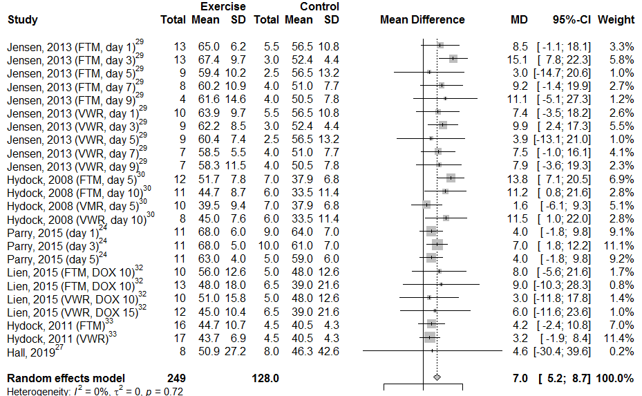

**1**

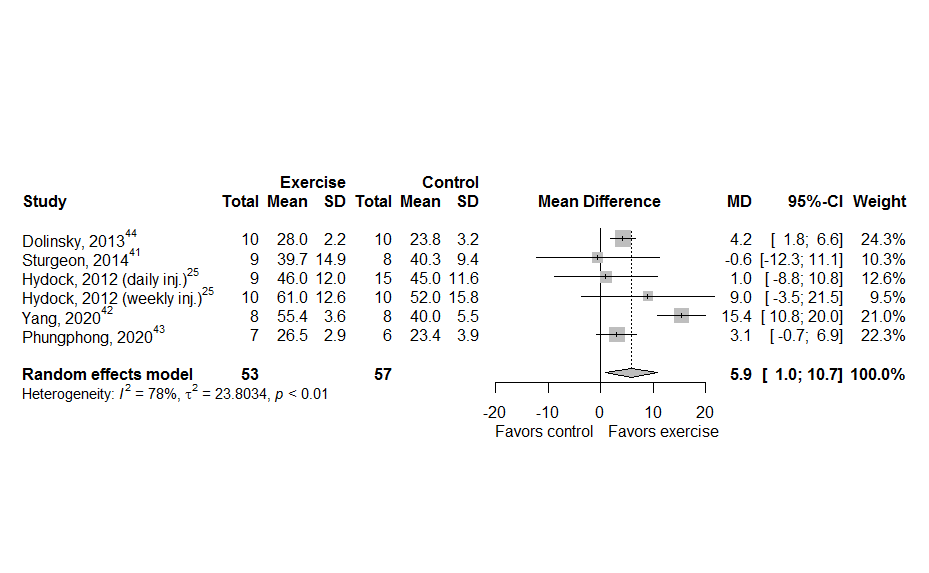

**2**

Data S5.

Results on +dP/dt and –dP/dt

For both +dP/dt and –dP/dt, results are favoring physical exercise groups (Figures S3-S6). In

+dp/dt, a pooled analysis of studies using forced exercise interventions demonstrated a MD

274.7; 725.9), T<sup>2</sup>=138438.2.

In –dP/dt, a MD of -374.5 (95%CI:-508.9; -240.1), T<sup>2</sup>=20895.3, and -407.5 (9%CI: -596.9; -

218.1) mm Hg was found for respectively forced and voluntary exercise interventions

compared to non-exercised rodents.

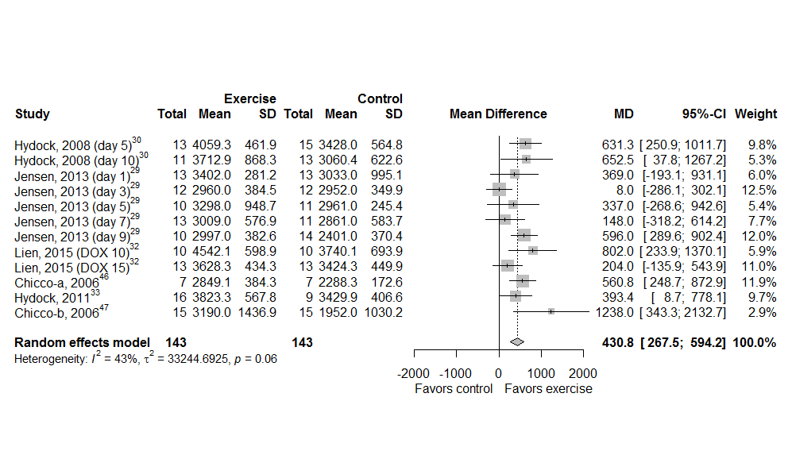

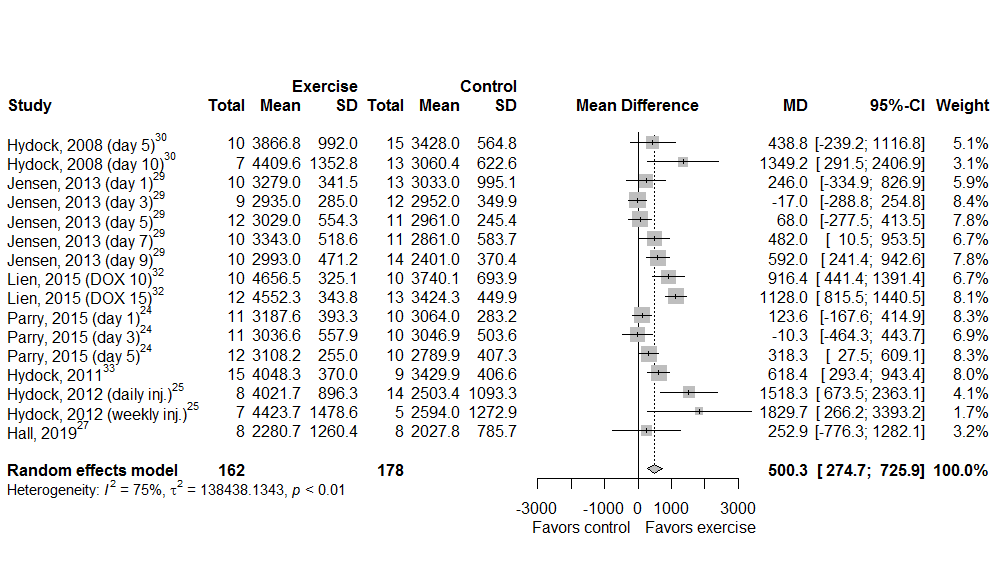

**3**

**4**

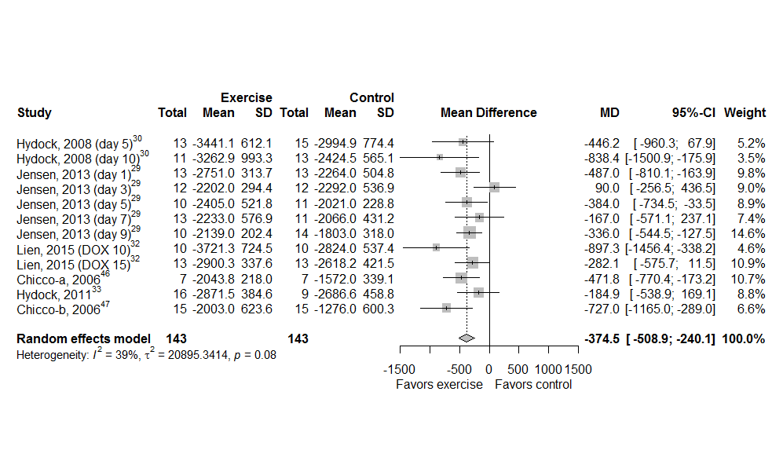

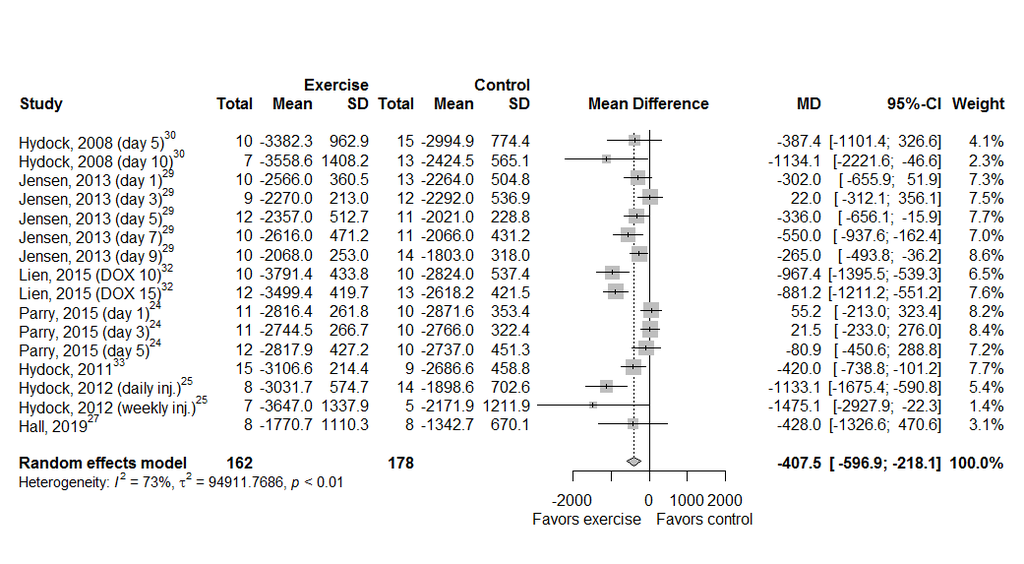

**5**

**6**